# Data Science Project - A Review of the Relationship Between Song Features and Its Relative Popularity With Respect to Time

Memes and Music: Rich Gude Siwei Yang Junhe Zhang Krystal Payton

April 22, 2020

# 1 Executive Summary:

The purpose of this study it to identify: Does the key, valence, tempo, or other musical attributes change between popular American songs, and not popular songs for contrast, from the 1960’s versus songs from the early 2000’s? Musical attributes under consideration are gathered from the Spotify Audio Analysis tool that records basic musical metrics, such as tempo, key, and mode, as well as more advanced, proprietary metrics, such as energy, valence, and danceability. Popular songs from each decade are identified as those that have appeared on the Billboard Hot 100, published by Billboard magazine. This study utilizes three predictive models, K-Nearest Neighbor, Decision Tree, and Logistic Regression, to predict the binary “popularity” feature, popular or not popular. If each model has greater than 50% accuracy (signifying it is superior to random guessing), then it can be determined that musical attributes *do* have an effect on song popularity, and the features that appear in each model are those that have the most significant impact.

From the three models explored above using popular and non-popular songs from the 1960’s and 2000’s decades and evaluating the musical attributes from therein, the answer to the SMART quesiton posed is **‘Yes’**. All three models had an accuracy significantly greater than 50%, fluctuating from 64% from the Logistic Regression modeling to 75% from the K-Nearest Neighbor models, identifying that, *‘Yes’*, musical attributes can be used to identify popular songs from non-popular songs, at least to some extent or at a given, non-50-50 probability (if they could not, the accuracy for each model would approximately be 50%), and, *‘Yes’*, these attributes can also change with time although there are some consistent attributes of popular songs through time.

The conclusion of this study, for the benefit of any aspiring song writer who wishes to produce popular, well-respected music, is to create songs that have a high energy, are easy to dance to, and are played in the major key, so as to evoke an uplifting mood in listeners as these attributes more likely to producing a popular song. Additional analysis, potentially reviewing lyrics, themes, or other musical attributes, may lead to additional insights into the structure and composition of popular songs to the benefit of musical scholars, artists, or profiteers.

# 2 Purpose:

The purpose of this study is to analyse the affect of music attributes, such as tempo, key, mode, etc, on the popularity of songs with respect to time. Specifically, the SMART question for this study is: Does the key, valence, tempo, or other musical attributes change between popular songs, and not popular songs for contrast, in the 1960’s versus songs from the early 2000’s?

The methodology by which this will be accomplished is to analyze song attribute data collected from Spotify using their application programming interface (API) and compare these attribute values between “popular” and not-“popular” songs from two decades, the 1960’s and the 2000’s. Spotify API attribute data collects the following features for every song, or “track”, under review: track, artist, key, mode, valence, tempo, “energy”, “liveness”, and “danceability”. The popularity of each song will be a binary attribute: A song will be considered popular if it appears in the Billboard Hot 100, a weekly top list of the popular tracks from each week measured by Billboard Magazine. Billboard Magazine is the widely considered standard for song popularity and has existed since the 1960s through today and, so, represents a consistent standard for measuring song popularity through time.

# 3 A Discussion of Basic Music Theory

Music, as an art, has a long and varied history depending on the era and geographical space in which an individual may be concerned. While the purpose of this study is to identify the change of popular music, at least over a short period since what is 50 years to the entire timeline of the human species over which music in some form is sure to have been evident, the entire history of what music is composed and how it is written or expressed will not be discussed herein. Instead, this study is focused on contemporary, American-produced songs, and so, certain objective measurements of song qualities, namely tempo, key, and mode, can be used to compare and contrast songs both across the musically spectrum, from say jazz to rock-and-roll, and through time.

Tempo, key, and mode are relatively basic concepts in music theory. The beat is the basic unit of time in music, the pace at which the music pulses; it is, essentially, when a listener would tap their toe during a song. **Tempo** is the speed or pace of a given song and is often measured in beats per minute. Certain genres of songs are defined by high tempos, like electric-dance music (EDM), but most genres vary considerably in their tempo. Pitch is the audio frequency at which individual notes within the song are heard by the listener. In general terms, the **key** of a song is the average pitch of a song, or the pitch around which a song fluctuates; performing a song in a higher key means that all of the notes of a song are increased at a level commiserate with the change in key (a major key change from “C’” to “D”, one pitch, would change the pitch of all notes in the song up pitch as well). Along the same concept as key, **mode** is the interval at which pitches are expressed in a song and is expressed as either “minor” or “major”. The key and mode are often expressed together when describing the pitch qualities of a song, such as “F major” or “D minor”. From an audio perspective, “major” keys are more often associated with and evoke happy or bright melodies, whereas “minor” keys may sound melancholic.

The concepts discussed here are general introduction to the features that will be discussed as part of this study’s dataset, and the format of this study herein, namely a written report, does not support audio examples, which would be necessary for any comprehensive understanding of music theory. Additional discussion of tempo, key, and mode, with audio examples for the differences between keys and modes, can be found [here](https://www.youtube.com/watch?v=rgaTLrZGlk0).

# 4 Data Selection:

As identified in the methodology statement, the data in this study is pulled from two corporate sources, Spotify Technology S.A. (Spotify) and the Billboard-Hollywood Media Group. Spotify is a popular online streaming service for music, videos, and podcasts. Spotify provides an “Audio Analysis” of a musical track that describes the structure of the track and its musical content, including tempo, key, and mode discussed above, in addition to more sophisticated musical metrics relating multiple core concepts of music. The advanced metrics that will be tracked from Spotify Audio Analysis in this study are valence, “danceability”, “energy”, and “liveness”; these metrics are discussed further below. The Billboard-Hollywood Media Group owns and produces the “Billboard” magazine. This publication is famous for the Billboard Hot 100 list, a weekly-published list that identifies the most popular, American songs of the week, based on sales and digital downloads and streams. The Billboard Hot 100 has been in publication since 1958 and establishes an objective standard for identifies popular songs for the purposes of this study.

Based on the source from which popular songs are determined, the conclusions of this study should only apply to songs produced or with a large-commerical release in the United States of America. Song features for popular songs based on similar metrics of sales and digital views from other countries may vary from the results reported herein.

The data analyized herein was pulled from the Kaggle database website, from a dataset collected and produced by user, Farooq Ansari. The specific dataset can be found [here](https://www.kaggle.com/theoverman/the-spotify-hit-predictor-dataset).

# 5 Data Background:

The full analysis of these features, namely the methods or calculations by which their values are determined, are not released by Spotify, potentially due to intellectual property reasons.

The Billboard Hot 100 has several component charts that contribute to the overall calculation of the Hot 100 each week. The most significant components are: [^2] - **Hot 100 Airplay**: (per Billboard) approximately 1,000 stations, “composed of adult contemporary, R&B, hip hop, country, rock, gospel, Latin and Christian formats, digitally monitored twenty-four hours a day, seven days a week. Charts are ranked by number of gross audience impressions, computed by cross-referencing exact times of radio airplay with Arbitron listener data.” - **Hot Singles Sales**: (per Billboard) “the top selling singles compiled from a national sample of retail store, mass merchant and internet sales reports collected, compiled, and provided by Nielsen SoundScan.” The chart is released weekly and measures sales of physical commercial singles. With the decline in sales of physical singles in the US, many songs that become number one on this chart often do not even chart on the Hot 100. - **Digital Songs**: Digital sales are tracked by Nielsen SoundScan and are included as part of a title’s sales points. - **Streaming Songs**: a collaboration between Billboard, Nielsen SoundScan and National Association of Recording Merchandisers which measures the top streamed radio songs, on-demand songs and videos on leading online music services.

From these varied and independent sources, the Billboard Hot 100 represents a nuetral and storied arbiter of the objective popularity of songs from 1958 thorough the present, including all songs to be evaluated from the 1960s and early 2000s.

# 6 Data Preprocessing

The Spotify Audio Analysis stores up to 42 music features for each track. For the purposes of this study, only the following variables will be analyzed and reviewed:

**Track Variables of Interest:**

1. Track: the name of the track
2. Artist: the name of the artist
3. Tempo: a float value for the beats per minute of the song
4. Key: an integer mapping of the standard pitch-class notation where: 0 = C key, 1 = C*#*/D*b*, 2 = D, and so on in rising key fashion up to 11 = B key.
5. Mode: an integer mapping for major (1) and minor (0) keys
6. Valence: a float value between 0 and 1 for the relative valence of the track (discussed in the Data Background)
7. Danceabilty: a float value between 0 and 1 for the relative danceability of the track (discussed in the Data Background)
8. Energy: a float value between 0 and 1 for the relative energy of the track (discussed in the Data Background)
9. Liveness: a float value between 0 and 1 for the relative liveness of the track (discussed in the Data Background)

For the purposes of data processing: key will be treated as a numeric value as the scaling nature of keys is suitable for modeling herein - each whole number change in key generally transposes to a constant change on the pitch scale, for C to C*#*/D*b* to D across numerals 0, 1, and 2 for example - and mode will be treated as a categorical (factor) value. In preprocessing the data, all of the variables from the Spotify data not listed above were eliminated from the study dataset.

The final feature, **Target**, was computed from the collective data from Billboard’s Hot 100 list as is represented as a categorical (factor) variable. Any track listed in the Billboard Hot 100 during the respective decade from which a track was released is given a value of 1, and any track not list at any point in the Billboard Hot 100 is given a 0.

This study will examine the change in music metrics affecting popularity with respect to time. For this purpose, this study will analyze two datasets, one with songs released during the 1960s, containing 8642 songs, and the other with songs released from the 2000s, containing 5872 songs. Each dataset is composed of an equal number of popular and not popular songs, 2936 popular and not popular songs from the 2000s and 4321 popular and not popular songs from the 1960s. For every song that appears in the Billboard Hot 100 list from their respective decade (with a target value of 1), another song from the same decade, not appearing in the Hot 100 was chosen to fill in the dataset for analytics and review. Non-popular songs that were chosen from American-produced songs at random from across music genres with the attempt to capture a suitable mix of music qualities.

A summary of the track musical features and their values from the entire 2000’s and 1960’s datasets are presented below:

```r
print('A Summary of the 1960\'s Dataset:')
```

[1] “A Summary of the 1960’s Dataset:”

```r
xkablesummary(data1960_X)
```

Table: Statistics summary.

|  | tempo | key | valence | danceability | energy | liveness | mode |
| --- | --- | --- | --- | --- | --- | --- | --- |
| Min | 0.0 | 0.00 | 0.000 | 0.000 | 0.001 | 0.014 | 0.000 |
| Q1 | 93.7 | 2.00 | 0.361 | 0.382 | 0.281 | 0.103 | 1.000 |
| Median | 112.4 | 5.00 | 0.602 | 0.501 | 0.436 | 0.148 | 1.000 |
| Mean | 115.1 | 5.08 | 0.575 | 0.492 | 0.445 | 0.214 | 0.756 |
| Q3 | 131.9 | 8.00 | 0.816 | 0.612 | 0.608 | 0.278 | 1.000 |
| Max | 241.0 | 11.00 | 0.993 | 0.922 | 0.995 | 0.984 | 1.000 |

```r
print('A Summary of the 2000\'s Dataset:')
```

[1] “A Summary of the 2000’s Dataset:”

```r
xkablesummary(data2000_X)
```

Table: Statistics summary.

|  | tempo | key | valence | danceability | energy | liveness | mode |
| --- | --- | --- | --- | --- | --- | --- | --- |
| Min | 46.8 | 0.00 | 0.000 | 0.059 | 0.000 | 0.019 | 0.000 |
| Q1 | 97.0 | 2.00 | 0.278 | 0.416 | 0.567 | 0.094 | 0.000 |
| Median | 120.0 | 5.00 | 0.486 | 0.556 | 0.744 | 0.131 | 1.000 |
| Mean | 121.6 | 5.28 | 0.482 | 0.543 | 0.695 | 0.196 | 0.645 |
| Q3 | 141.5 | 8.00 | 0.687 | 0.681 | 0.885 | 0.263 | 1.000 |
| Max | 213.2 | 11.00 | 0.982 | 0.986 | 0.999 | 0.987 | 1.000 |

# 7 Variable Anaylsis and Approach - Rich

# 8 Exploratory Data Analysis - Rich

A cursory review of the song feature values for just popular between the two decades, shown below, shows a difference in the mean values for multiple song features, for instance: From the 1960’s to the early 2000’s, the mean valence noticeably decreases while the mean danceability and energy values noticeably increase.

```r
# Provide a summary of the columns and data within the data
print('A Summary of the Popular 2000\'s Tracks:')
```

```
## [1] "A Summary of the Popular 2000's Tracks:"
```

```r
xkablesummary(subset(data2000, target == 1, select = c('tempo', 'key', 'valence', 'danceability', 'energy', 'liveness', 'mode')))
```

Table: Statistics summary.

|  | tempo | key | valence | danceability | energy | liveness | mode |
| --- | --- | --- | --- | --- | --- | --- | --- |
| Min | 60.0 | 0.00 | 0.039 | 0.113 | 0.107 | 0.019 | 0.000 |
| Q1 | 96.1 | 2.00 | 0.373 | 0.527 | 0.607 | 0.090 | 0.000 |
| Median | 118.4 | 5.00 | 0.565 | 0.632 | 0.736 | 0.129 | 1.000 |
| Mean | 120.3 | 5.26 | 0.554 | 0.630 | 0.715 | 0.184 | 0.691 |
| Q3 | 140.0 | 8.00 | 0.731 | 0.735 | 0.845 | 0.243 | 1.000 |
| Max | 210.9 | 11.00 | 0.973 | 0.986 | 0.996 | 0.985 | 1.000 |

```r
print('A Summary of the Popular 1960\'s Tracks:')
```

```
## [1] "A Summary of the Popular 1960's Tracks:"
```

```r
xkablesummary(subset(data1960, target == 1, select = c('tempo', 'key', 'valence', 'danceability', 'energy', 'liveness', 'mode')))
```

Table: Statistics summary.

|  | tempo | key | valence | danceability | energy | liveness | mode |
| --- | --- | --- | --- | --- | --- | --- | --- |
| Min | 0.0 | 0.00 | 0.000 | 0.000 | 0.018 | 0.014 | 0.000 |
| Q1 | 97.5 | 2.00 | 0.496 | 0.430 | 0.364 | 0.101 | 1.000 |
| Median | 116.4 | 5.00 | 0.699 | 0.537 | 0.502 | 0.155 | 1.000 |
| Mean | 118.7 | 5.14 | 0.663 | 0.531 | 0.511 | 0.219 | 0.839 |
| Q3 | 134.7 | 8.00 | 0.862 | 0.638 | 0.660 | 0.285 | 1.000 |
| Max | 241.0 | 11.00 | 0.991 | 0.922 | 0.995 | 0.984 | 1.000 |

A presentation and analysis of the distributions of each of the variables prior to modeling is presented below. For each histogram, data from the 1960’s will be presented consistently in blue, while data from the 2000’s will be presented in red. Data from popular songs will be displayed in histograms overlaping the collective data with a darker shade of blue or red for 1960 and 2000 data, respectively. The Shapiro-Wilke Test for determining normality of data has a null hypothesis (H<sub>0</sub>:) stating the data is normally distributed; that is to say, a probablity value below 0.05 (corresponding to a confidence interval of 95%) from the test means that the null hypothesis must be rejected, and the data to which the test was applied is not normally-distributed.

When comparing the statistical equivalency of two values, a Two-Tailed T-Test is performed to determine whether the two values are statistically equivalent. The null hypothesis for the Two-Tailed T-Test ((H<sub>0</sub>:) is that the two values are statistically equivalent (or their true difference in mean value is equal to 0); that is to say, a probability value less than 0.025 (corresponding to a confidence interval of 95%) from the test means that the null hypothesis must be rejected, and the two values are **not** statistically equivalent. If the mean values between popular and non-popular songs or popoular songs between decades for a particular feature are **not** statisitically different, it most probably means that the feature is not unique between either classification and will not be considered significant during model processing.

## 8.1 An Exploration of Tempo

### 8.1.1 Tempo Histograms

Discussed above, **Tempo** is the speed or pace of a given song and is often measured in beats per minute. Distributions of the tempo of 8642 songs from the 1960’s and 5872 songs from the 2000’s are presented below with darker shades showing the distributions of the popular songs within each dataset and the mean value of each set represented by a dashed line:

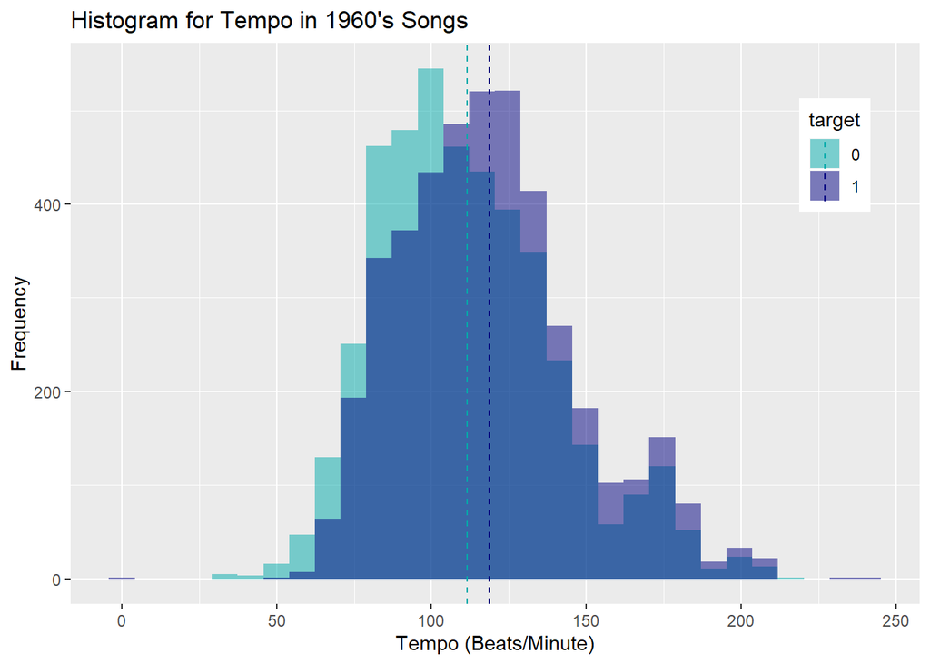

```r
# Set up a conditional for mean lines
temp60Line <- ddply(data1960, "target", summarise, tempo.mean=mean(tempo))
temp00Line <- ddply(data2000, "target", summarise, tempo.mean=mean(tempo))

# Produce a two part graph for popular and non-popular songs from 1960
ggplot(data = data1960, aes(x = tempo, fill = target)) +
  geom_histogram(position = "identity", alpha = 0.5) +
  labs(title="Histogram for Tempo in 1960's Songs") +
  labs(x="Tempo (Beats/Minute)", y="Frequency") +
  theme(legend.position=c(0.9, 0.8)) +
  scale_color_manual(values=c("#00aaaa", "#000080")) +
  scale_fill_manual(values=c("#00aaaa", "#000080")) +
  geom_vline(data= temp60Line, aes(xintercept=tempo.mean, color=target),
             linetype="dashed")
```

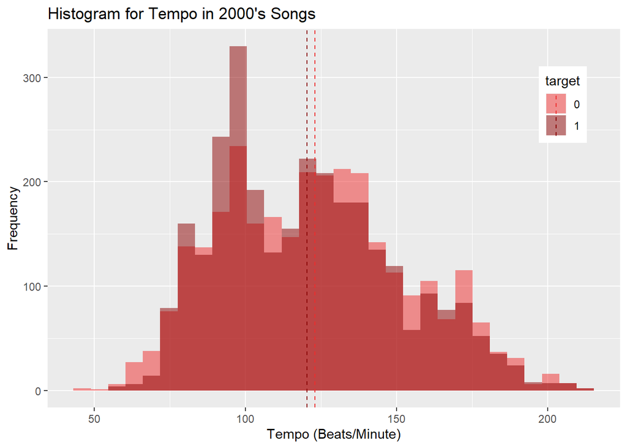

```r
# Produce a two part graph for popular and non-popular songs from 2000
ggplot(data = data2000, aes(x = tempo, fill = target)) +
  geom_histogram(position = "identity", alpha = 0.5) +
  labs(title="Histogram for Tempo in 2000's Songs") +
  labs(x="Tempo (Beats/Minute)", y="Frequency") +
  theme(legend.position=c(0.9, 0.8)) +
  scale_color_manual(values=c("firebrick2", "red4")) +
  scale_fill_manual(values=c("firebrick2", "red4")) +
  geom_vline(data= temp00Line, aes(xintercept=tempo.mean, color=target),
             linetype="dashed")
```

From the general trends in the histogram data above, it can be seen that the tempo for popular songs in 1960 skews higher than for non-popular songs, from an average tempo of 118.743 beats per minute for popular songs versus 111.508 beats per minute for non-popular songs. Whereas the reverse is true for popular songs in the 2000’s - the tempo for popular songs in 2000 skews lower than for non-popular songs, from an average tempo of 120.284 beats per minute for popular songs versus 122.942 beats per minute for non-popular songs.

The distributions of tempo for just the popular songs from the two decades under review are presented below:

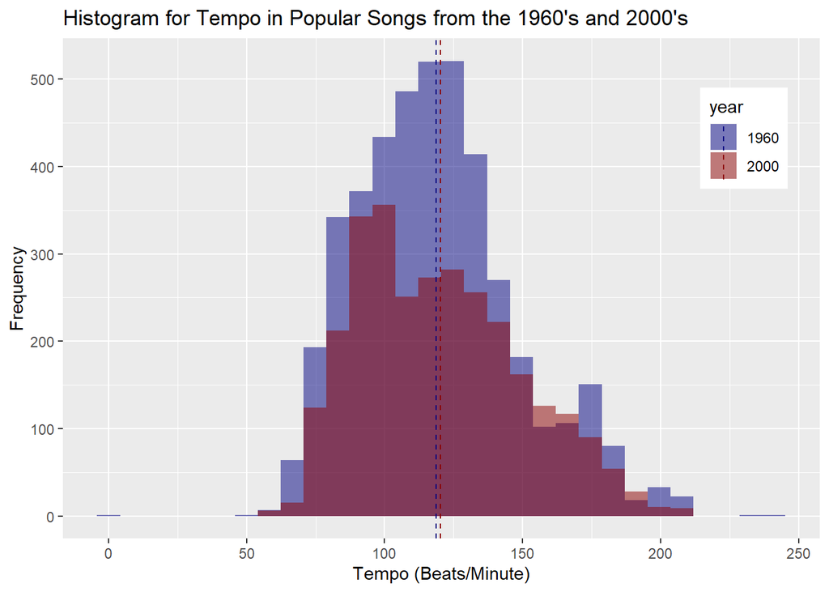

```r
# Set up a conditional for mean lines
tempPopLine <- ddply(dataPopular, "year", summarise, tempo.mean=mean(tempo))

# Produce a two part graph for popular and non-popular songs from 1960
ggplot(data = dataPopular, aes(x = tempo, fill = year)) +
  geom_histogram(position = "identity", alpha = 0.5) +
  labs(title="Histogram for Tempo in Popular Songs from the 1960's and 2000's") +
  labs(x="Tempo (Beats/Minute)", y="Frequency") +
  theme(legend.position=c(0.9, 0.8)) +
  scale_color_manual(values=c("#000080", "red4")) +
  scale_fill_manual(values=c("#000080", "red4")) +
  geom_vline(data= tempPopLine, aes(xintercept=tempo.mean, color=year),
             linetype="dashed")
```

From the general trend in the histogram data above, it can be seen that the tempo distribution of popular songs is different between the two decades, with the 1960’s having a sharper peak of tempos near the mean for the decade and the 2000’s distribution being more skewed left in comparison. The mean tempo of either decade appears to be distinct as well, but only just so - the two values are very similar. Additional T-Testing may confirm if the two values can be considered statistically equivalent or not.

### 8.1.2 Tempo Normality Testing

While the shape of each of the histograms from each decade and popularity potentially appear normally-distributed, the Shapiro-Wilke Test (H<sub>0</sub>: the data is normally-distributed) identifies the following for each sub-category of decade and popularity:

**Shapiro-Wilke Normality Test:** 1960’s Popular Probabality Value: 1.377e-27 1960’s Non-Popular Probabality Value: 2.976e-28 2000’s Popular Probabality Value: 1.972e-24 2000’s Non-Popular Probabality Value: 7.446e-17

For all of the categories above, the Shapiro-Wilke probability was significantly less than 0.05 and, thus, the data is not normally distributed.

### 8.1.3 Tempo Difference Among Popular Songs Between Decades

Considering only popular music, the mean tempo for 1960’s music is 119 beats per minute, and the mean tempo for 2000’s music is 120 beats per minute. A Two-Tailed T-Test (H<sub>0</sub>: the two means are statistically equivalent or their true difference in mean value is equal to 0) is performed to determine whether the two mean tempos from either decade are statistically equivalent:

```r
# Perform tst
ttest_tempo = t.test(subset(data1960,target ==1)$tempo, subset(data2000,target ==1)$tempo)
ttest_tempo
```

```
##
##  Welch Two Sample t-test
##
## data:  subset(data1960, target == 1)$tempo and subset(data2000, target == 1)$tempo
## t = -2, df = 6228, p-value = 0.03
## alternative hypothesis: true difference in means is not equal to 0
## 95 percent confidence interval:
##  -2.91 -0.17
## sample estimates:
## mean of x mean of y
##       119       120
```

With a probability value of 0.028 (p > 0.025), the T-Test null hypothesis is **not** rejected (albeit just barely), and the mean tempo values between the 1960’s and 2000’s decades should be considered equivalent (or their true difference in means is equal to 0).

From the additional T-Testing below, the mean tempo values between popular and non-popular songs from each decade should **not** be considered equivalent (or their true difference in means is not equal to 0)

```r
# Perform tst
ttest_tempo60 = t.test(subset(data1960,target ==0)$tempo, subset(data1960,target ==1)$tempo)
ttest_tempo60
```

```
##
##  Welch Two Sample t-test
##
## data:  subset(data1960, target == 0)$tempo and subset(data1960, target == 1)$tempo
## t = -12, df = 8640, p-value <2e-16
## alternative hypothesis: true difference in means is not equal to 0
## 95 percent confidence interval:
##  -8.46 -6.01
## sample estimates:
## mean of x mean of y
##       112       119
```

```r
ttest_tempo00 = t.test(subset(data2000,target ==0)$tempo, subset(data2000,target ==1)$tempo)
ttest_tempo00
```

```
##
##  Welch Two Sample t-test
##
## data:  subset(data2000, target == 0)$tempo and subset(data2000, target == 1)$tempo
## t = 3, df = 5858, p-value = 7e-04
## alternative hypothesis: true difference in means is not equal to 0
## 95 percent confidence interval:
##  1.12 4.20
## sample estimates:
## mean of x mean of y
##       123       120
```

The conclusion of the exploratory data analysis of song tempo in the two datasets from the 1960’s and the 2000’s is no collection of popular or non-popular songs were normally-distributed, and the mean values in tempo were distinct (non-equivalent) between popular and non-popular songs in each decade, but the mean values between popular songs from each decade were not distinct.

## 8.2 An Exploration of Key

### 8.2.1 Key Histograms

Discussed above, the **Key** of a song is the average pitch of a song, or the pitch around which a song fluctuates. There are 12 keys represented in the integer mapping from both the 1960’s and 2000’s data; specifically, the following intergers map to the accompanying keys: 0 = C key, 1 = C*#*/D*b*, 2 = D, 3 = D*#*/E*b*, 4 = E, 5 = F, 6 = F*#*/G*b*, 7 = G, 8 = G*#*/A*b*, 9 = A, 10 = A*#*/B*b*, and 11 = B. Distributions of the keys of 8642 songs from the 1960’s and 5872 songs from the 2000’s are presented below with darker shades showing the distributions of the popular songs within each dataset and the mean value of each set represented by a dashed line:

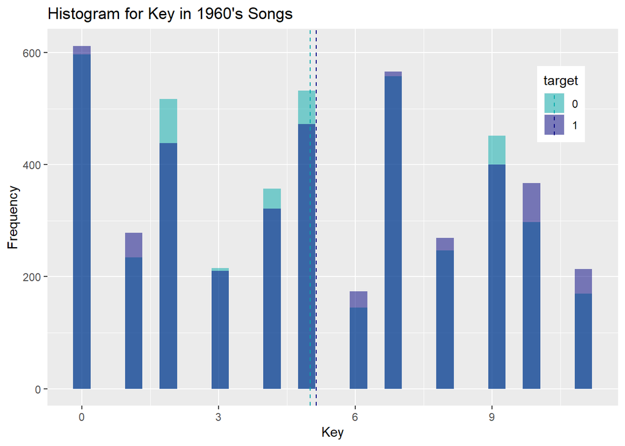

```r
# Set up a conditional for mean lines
key60Line <- ddply(data1960, "target", summarise, key.mean=mean(key))
key00Line <- ddply(data2000, "target", summarise, key.mean=mean(key))

# Produce a two part graph for popular and non-popular songs from 1960
ggplot(data = data1960, aes(x = key, fill = target)) +
  geom_histogram(position = "identity", alpha = 0.5) +
  labs(title="Histogram for Key in 1960's Songs") +
  labs(x="Key", y="Frequency") +
  theme(legend.position=c(0.9, 0.8)) +
  scale_color_manual(values=c("#00aaaa", "#000080")) +
  scale_fill_manual(values=c("#00aaaa", "#000080")) +
  geom_vline(data= key60Line, aes(xintercept=key.mean, color=target),
             linetype="dashed")
```

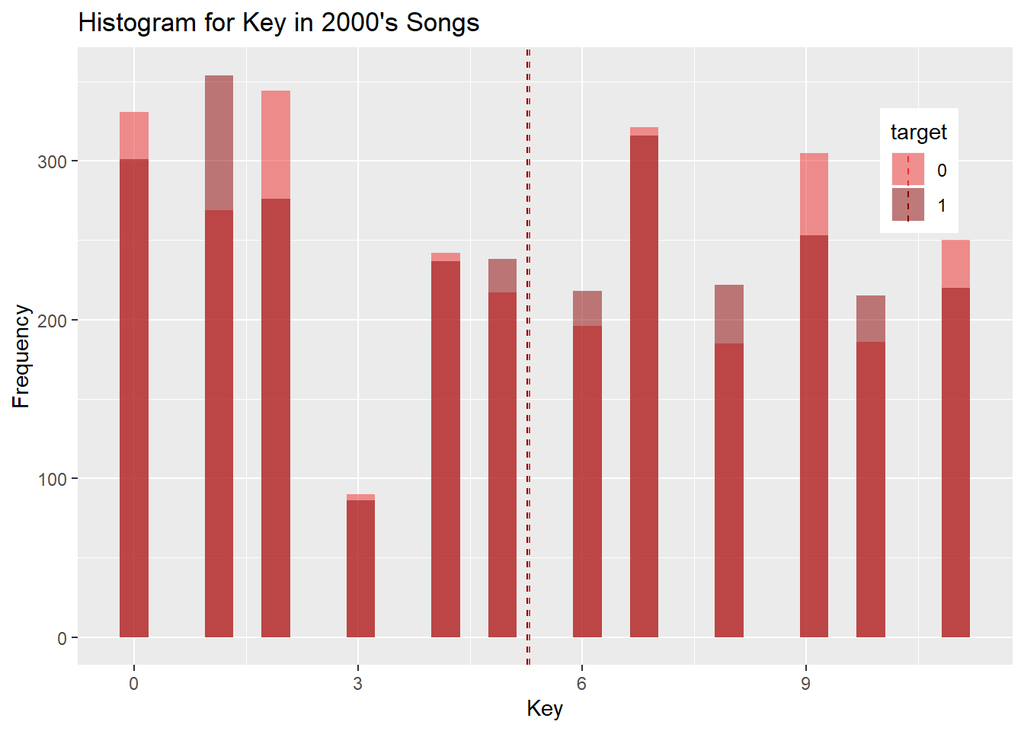

```r
# Produce a two part graph for popular and non-popular songs from 2000
ggplot(data = data2000, aes(x = key, fill = target)) +
  geom_histogram(position = "identity", alpha = 0.5) +
  labs(title="Histogram for Key in 2000's Songs") +
  labs(x="Key", y="Frequency") +
  theme(legend.position=c(0.9, 0.8)) +
  scale_color_manual(values=c("firebrick2", "red4")) +
  scale_fill_manual(values=c("firebrick2", "red4")) +
  geom_vline(data= key00Line, aes(xintercept=key.mean, color=target),
             linetype="dashed")
```

From the general trends in the histogram data above, there may be a slight higher shift in the distribution of keys for popular songs in 1960 versus the keys of non-popular songs, from an average key of 5.14 for popular songs versus 5.013 for non-popular songs. Whereas the reverse may be true for popular songs in the 2000’s - the key for popular songs in 2000 skews just slightly lower than for non-popular songs, from an average key of 5.261 for popular songs versus 5.292 for non-popular songs, although the difference appearance to be negligible.

The distributions of key for just the popular songs from the two decades under review are presented below:

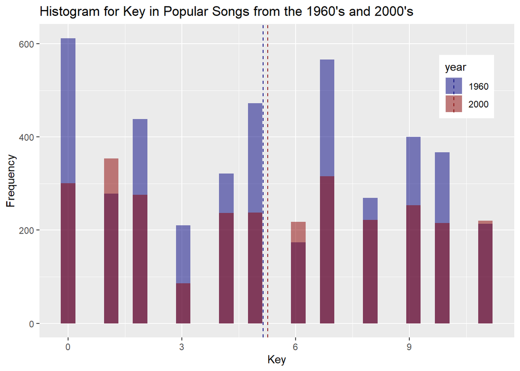

```r
# Set up a conditional for mean lines
keyPopLine <- ddply(dataPopular, "year", summarise, key.mean=mean(key))

# Produce a two part graph for popular and non-popular songs from 1960
ggplot(data = dataPopular, aes(x = key, fill = year)) +
  geom_histogram(position = "identity", alpha = 0.5) +
  labs(title="Histogram for Key in Popular Songs from the 1960's and 2000's") +
  labs(x="Key", y="Frequency") +
  theme(legend.position=c(0.9, 0.8)) +
  scale_color_manual(values=c("#000080", "red4")) +
  scale_fill_manual(values=c("#000080", "red4")) +
  geom_vline(data= keyPopLine, aes(xintercept=key.mean, color=year),
             linetype="dashed")
```

From the general trend in the histogram data above, it can be seen that the tempo distribution of popular songs is different between the two decades, with the 1960’s trending to the lower key values in comparison to the 2000’s distribution. The mean key of either decade appears to be distinct as well with the 1960’s having a lower average key in comparison to the 2000’s. Additional T-Testing may confirm if the two values can be considered statistically equivalent or not.

### 8.2.2 Key Normality Testing

The shape of each of the histograms from each decade and popularity do not appear normally-distributed; instead they appear closer to a uniform distribution. To confirm this observation, the Shapiro-Wilke Test (H<sub>0</sub>: the data is normally-distributed) identifies the following for each sub-category of decade and popularity for key distributions:

**Shapiro-Wilke Normality Test:** 1960’s Popular Probabality Value: 8.897e-41 1960’s Non-Popular Probabality Value: 1.23e-39 2000’s Popular Probabality Value: 3.294e-35 2000’s Non-Popular Probabality Value: 1.54e-35

For all of the categories above, the Shapiro-Wilke probability was significantly less than 0.05 and, thus, none of the key distributions should be considered normally-distributed.

### 8.2.3 Key Difference Among Popular Songs Between Decades

Considering only popular music, the mean key for 1960’s music is 5, and the mean key for 2000’s music is 5. A Two-Tailed T-Test (H<sub>0</sub>: the two means are statistically equivalent or their true difference in mean value is equal to 0) is performed to determine whether the two mean keys from either decade are statistically equivalent:

```r
# Perform t-test
ttest_key = t.test(subset(data1960,target ==1)$key, subset(data2000,target ==1)$key)
ttest_key
```

```
##
##  Welch Two Sample t-test
##
## data:  subset(data1960, target == 1)$key and subset(data2000, target == 1)$key
## t = -1, df = 6248, p-value = 0.2
## alternative hypothesis: true difference in means is not equal to 0
## 95 percent confidence interval:
##  -0.2859  0.0448
## sample estimates:
## mean of x mean of y
##      5.14      5.26
```

With a probability value of 0.153 (p > 0.025), the T-Test null hypothesis is **not** rejected, and the mean key values between the 1960’s and 2000’s decades should be considered equivalent (or their true difference in means is equal to 0).

```r
# Perform tst
ttest_key60 = t.test(subset(data1960,target ==0)$key, subset(data1960,target ==1)$key)
ttest_key60
```

```
##
##  Welch Two Sample t-test
##
## data:  subset(data1960, target == 0)$key and subset(data1960, target == 1)$key
## t = -2, df = 8633, p-value = 0.09
## alternative hypothesis: true difference in means is not equal to 0
## 95 percent confidence interval:
##  -0.2725  0.0184
## sample estimates:
## mean of x mean of y
##      5.01      5.14
```

```r
ttest_key00 = t.test(subset(data2000,target ==0)$key, subset(data2000,target ==1)$key)
ttest_key00
```

```
##
##  Welch Two Sample t-test
##
## data:  subset(data2000, target == 0)$key and subset(data2000, target == 1)$key
## t = 0.3, df = 5869, p-value = 0.7
## alternative hypothesis: true difference in means is not equal to 0
## 95 percent confidence interval:
##  -0.151  0.214
## sample estimates:
## mean of x mean of y
##      5.29      5.26
```

The conclusion of the exploratory data analysis of song key in the two datasets from the 1960’s and the 2000’s is no collection of popular or non-popular songs were normally-distributed, and the mean values in key were not distinct between popular and non-popular songs in each decade and between popular songs from each decade.

## 8.3 An Exploration of Mode

### 8.3.1 Mode Bar Charts

Discussed above, the **Mode** of a song is the interval at which pitches are expressed in a song and is expressed as either “minor” or “major”, where the major key is associated with melodies that are cheery or bright while the minor key is associated with melancholic melodies. The mode is a binary categorical variable with an integer mapping of 0 for minor keys and 1 for major keys. Bar charts of the mode values of 8642 songs from the 1960’s and 5872 songs from the 2000’s are presented below with darker shades showing the mode values of the popular songs within each dataset (bars are not overlapping):

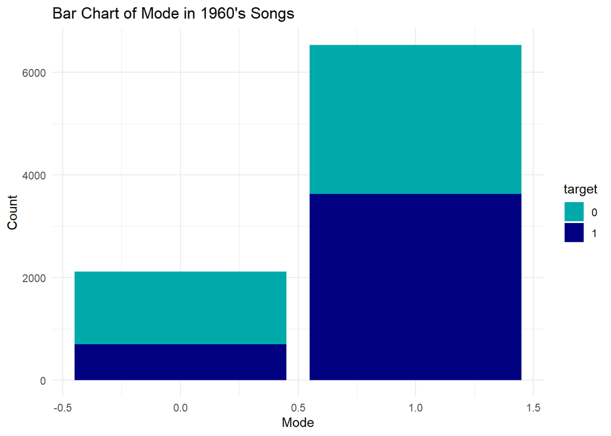

```r
# Produce a two part bar chart for popular and non-popular songs from 1960
ggplot(data = data1960, aes(mode)) +
  geom_bar(aes(fill = target)) +
  labs(title="Bar Chart of Mode in 1960's Songs") +
  labs(x="Mode", y="Count") +
  theme(legend.position=c(0.9, 0.8)) +
  scale_fill_manual(values=c("#00aaaa", "#000080")) +
  theme_minimal()
```

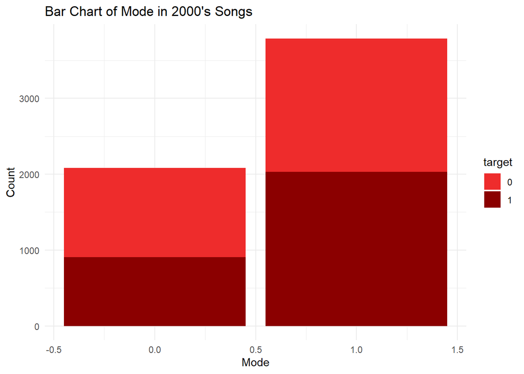

```r
# Produce a two part bar chart for popular and non-popular songs from 1960
ggplot(data = data2000, aes(mode)) +
  geom_bar(aes(fill = target)) +
  labs(title="Bar Chart of Mode in 2000's Songs") +
  labs(x="Mode", y="Count") +
  theme(legend.position=c(0.9, 0.8)) +
  scale_fill_manual(values=c("firebrick2", "red4")) +
  theme_minimal()
```

The percentage of popular songs from the 1960’s with a major key (mode = 1) is 83.893%, which is greater than the percentage of non-popular songs from the 1960’s with a major key at 67.23%. Similarly, the percentage of popular songs from the 2000’s with a major key (69.108%) is greater than the percentage of non-popular songs with a major key (59.911%). These trends show a general shift in popular songs towards the major key which is associated with happy or bright melodies compared to non-popular songs.

A bar chart of the mode values for just the popular songs from the two decades under review is presented below:

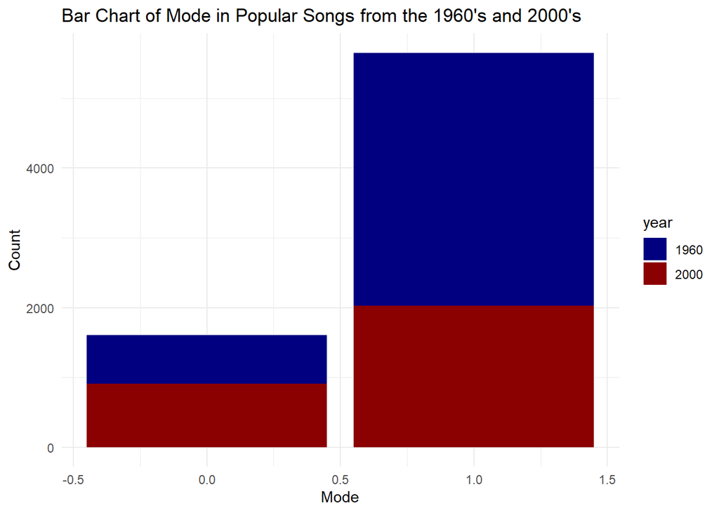

```r
# Produce a two part bar chart for popular songs from both decades
ggplot(data = dataPopular, aes(mode)) +
  geom_bar(aes(fill = year)) +
  labs(title="Bar Chart of Mode in Popular Songs from the 1960's and 2000's") +
  labs(x="Mode", y="Count") +
  theme(legend.position=c(0.9, 0.8)) +
  scale_fill_manual(values=c("#000080", "red4")) +
  theme_minimal()
```

The percentage of songs that are in the major key from popular 1960’s songs (83.893%) appears to be significantly higher than the percentage of songs that are in the major key from popular 2000’s songs (69.108%). Additional T-Testing may confirm if the two values can be considered statistically different or not.

### 8.3.2 Mode Difference Among Popular Songs Between Decades

Considering only popular music, the mean mode (equivalent to the percentage of songs with a major key mode) for 1960’s music is 0.839, and the mean key for 2000’s music is 0.691. A Two-Tailed T-Test (H<sub>0</sub>: the two means are statistically equivalent or their true difference in mean value is equal to 0) is performed to determine whether the two mean keys from either decade are statistically equivalent:

```r
# Perform t-test
ttest_mode = t.test((subset(data1960, target==1)$mode), (subset(data2000, target==1)$mode))
ttest_mode
```

```
##
##  Welch Two Sample t-test
##
## data:  (subset(data1960, target == 1)$mode) and (subset(data2000, target == 1)$mode)
## t = 14, df = 5332, p-value <2e-16
## alternative hypothesis: true difference in means is not equal to 0
## 95 percent confidence interval:
##  0.128 0.168
## sample estimates:
## mean of x mean of y
##     0.839     0.691
```

With a probability value of 9.7710^{-47} (p < 0.025), the T-Test null hypothesis is rejected, and the mean mode values between the 1960’s and 2000’s decades should **not** be considered equivalent (or their true difference in means is not equal to 0). The 1960’s had a statistically significant greater proportion of popular songs in the major key compared to popular songs in the 2000’s.

From the additional T-Testing below, the mean mode values between popular and non-popular songs from each decade should **not** be considered equivalent (or their true difference in means is not equal to 0)

```r
# Perform tst
ttest_mode60 = t.test(subset(data1960,target ==0)$mode, (subset(data1960,target ==1)$mode))
ttest_mode60
```

```
##
##  Welch Two Sample t-test
##
## data:  subset(data1960, target == 0)$mode and (subset(data1960, target == 1)$mode)
## t = -18, df = 8171, p-value <2e-16
## alternative hypothesis: true difference in means is not equal to 0
## 95 percent confidence interval:
##  -0.184 -0.149
## sample estimates:
## mean of x mean of y
##     0.672     0.839
```

```r
ttest_mode00 = t.test(subset(data2000,target ==0)$mode, (subset(data2000,target ==1)$mode))
ttest_mode00
```

```
##
##  Welch Two Sample t-test
##
## data:  subset(data2000, target == 0)$mode and (subset(data2000, target == 1)$mode)
## t = -7, df = 5850, p-value = 2e-13
## alternative hypothesis: true difference in means is not equal to 0
## 95 percent confidence interval:
##  -0.1163 -0.0676
## sample estimates:
## mean of x mean of y
##     0.599     0.691
```

The conclusion of the exploratory data analysis of song mode in the two datasets from the 1960’s and the 2000’s is the mean values in mode were distinct (non-equivalent) between popular and non-popular songs in each decade and between popular songs from each decade.

## 8.4 An Exploration of Valence

### 8.4.1 Valence Histograms

Discussed above, the **Valence** describes the musical positiveness conveyed by a track. Tracks with high valence sound more positive (e.g. happy, cheerful, euphoric), while tracks with low valence sound more negative (e.g. sad, depressed, angry). Valence is a numerical value between 0 and 1, inclusive. Distributions of the valence values of 8642 songs from the 1960’s and 5872 songs from the 2000’s are presented below with darker shades showing the distributions of the popular songs within each dataset and the mean value of each set represented by a dashed line:

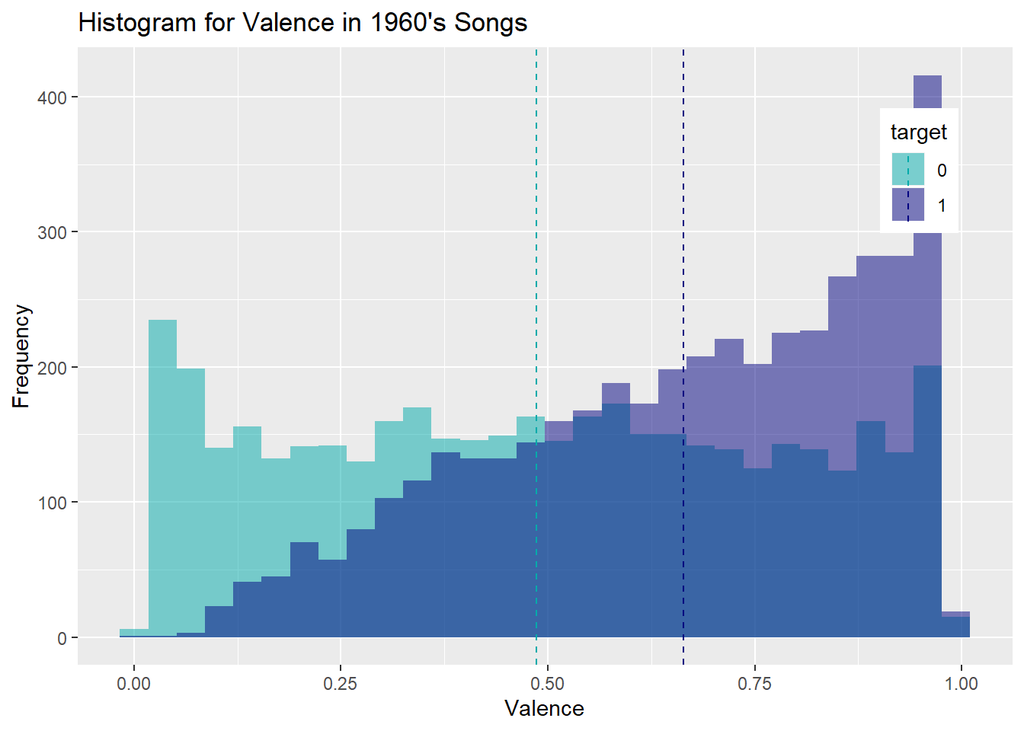

```r
# Set up a conditional for mean lines
val60Line <- ddply(data1960, "target", summarise, val.mean=mean(valence))
val00Line <- ddply(data2000, "target", summarise, val.mean=mean(valence))

# Produce a two part graph for popular and non-popular songs from 1960
ggplot(data = data1960, aes(x = valence, fill = target)) +
  geom_histogram(position = "identity", alpha = 0.5) +
  labs(title="Histogram for Valence in 1960's Songs") +
  labs(x="Valence", y="Frequency") +
  theme(legend.position=c(0.9, 0.8)) +
  scale_color_manual(values=c("#00aaaa", "#000080")) +
  scale_fill_manual(values=c("#00aaaa", "#000080")) +
  geom_vline(data= val60Line, aes(xintercept=val.mean, color=target),
             linetype="dashed")
```

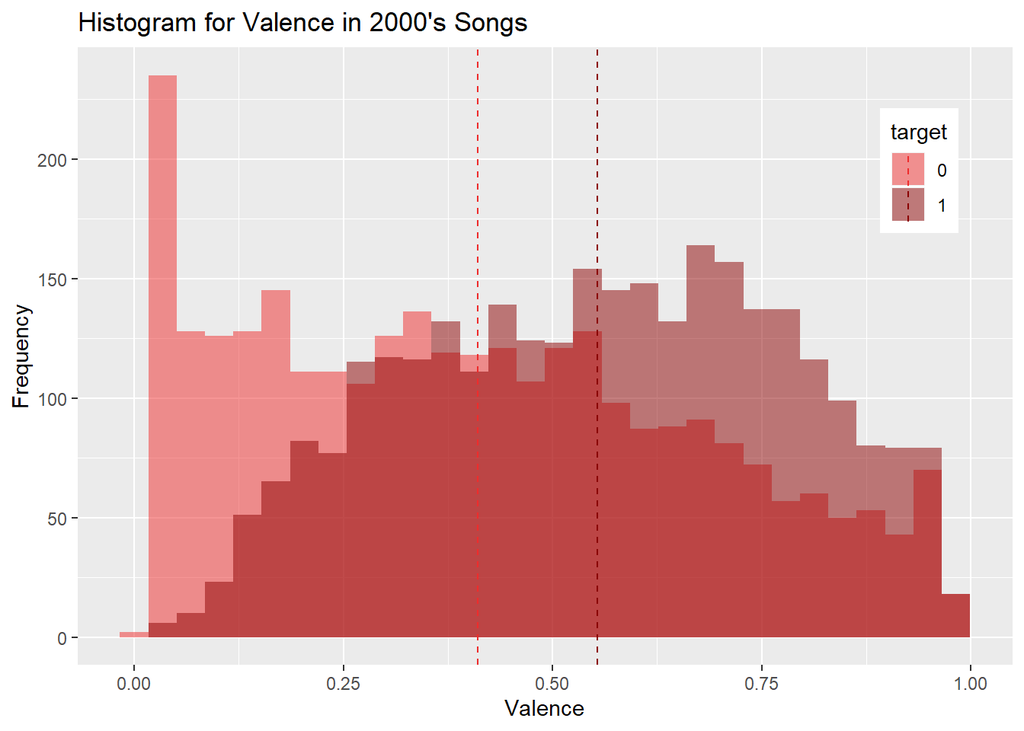

```r
# Produce a two part graph for popular and non-popular songs from 2000
ggplot(data = data2000, aes(x = valence, fill = target)) +
  geom_histogram(position = "identity", alpha = 0.5) +
  labs(title="Histogram for Valence in 2000's Songs") +
  labs(x="Valence", y="Frequency") +
  theme(legend.position=c(0.9, 0.8)) +
  scale_color_manual(values=c("firebrick2", "red4")) +
  scale_fill_manual(values=c("firebrick2", "red4")) +
  geom_vline(data= val00Line, aes(xintercept=val.mean, color=target),
             linetype="dashed")
```

From the general trends in the histogram data above, there is a clear right shift in the distribution of valence values (towards more positive and uplifting qualities) for popular songs in the 1960’s and 2000’s compared to the valence values of non-popular songs, from an average valence of 0.663 and 0.554 for popular songs in the 1960’s and 2000’s, respectively, versus 0.487 and 0.411 for non-popular songs in the 1960’s and 2000’s, respectively. In addition, none of the distributions of valence values appear to be normally-distributed.

The distributions of valence values for just the popular songs from the two decades under review are presented below:

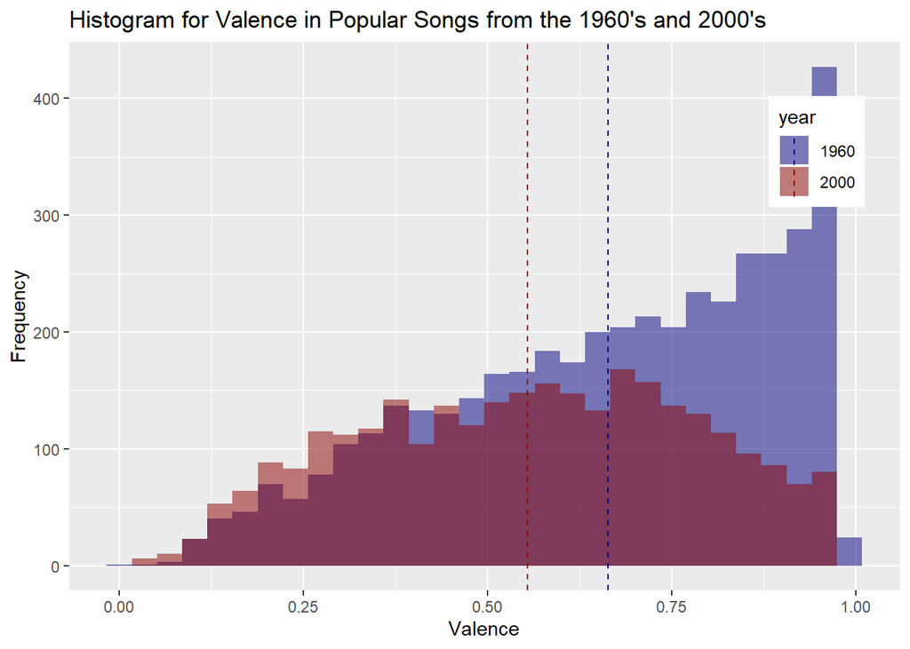

```r
# Set up a conditional for mean lines
valPopLine <- ddply(dataPopular, "year", summarise, val.mean=mean(valence))

# Produce a two part graph for popular and non-popular songs from 1960
ggplot(data = dataPopular, aes(x = valence, fill = year)) +
  geom_histogram(position = "identity", alpha = 0.5) +
  labs(title="Histogram for Valence in Popular Songs from the 1960's and 2000's") +
  labs(x="Valence", y="Frequency") +
  theme(legend.position=c(0.9, 0.8)) +
  scale_color_manual(values=c("#000080", "red4")) +
  scale_fill_manual(values=c("#000080", "red4")) +
  geom_vline(data= valPopLine, aes(xintercept=val.mean, color=year),
             linetype="dashed")
```

From the general trend in the histogram data above, it can be seen that the valence distribution of popular songs is different between the two decades, with the 1960’s trending to higher valence values in comparison to the 2000’s distribution. The mean valence of either decade appears to be distinct as well with the 1960’s having a much higher, average valence value in comparison to the 2000’s. Additional T-Testing may confirm if the two values can be considered statistically different or not.

### 8.4.2 Valence Normality Testing

The shape of each of the histograms from each decade and popularity do not appear normally-distributed; instead they appear closer to a uniform distribution or triangular in the case of popular 1960’s songs and non-popular 2000’s songs. To confirm this observation, the Shapiro-Wilke Test (H<sub>0</sub>: the data is normally-distributed) identifies the following for each sub-category of decade and popularity for valence distributions:

**Shapiro-Wilke Normality Test:** 1960’s Popular Probabality Value: 1.482e-37 1960’s Non-Popular Probabality Value: 2.117e-35 2000’s Popular Probabality Value: 6.23e-21 2000’s Non-Popular Probabality Value: 4.375e-29

For all of the categories above, the Shapiro-Wilke probability was significantly less than 0.05 and, thus, none of the valence distributions should be considered normally-distributed.

### 8.4.3 Valence Difference Among Popular Songs Between Decades

Considering only popular music, the mean valence for 1960’s music is 0.663, and the mean valence for 2000’s music is 0.554. A Two-Tailed T-Test (H<sub>0</sub>: the two means are statistically equivalent or their true difference in mean value is equal to 0) is performed to determine whether the two mean valence values from either decade are statistically equivalent:

```r
# Perform t-test
ttest_val = t.test(subset(data1960,target ==1)$valence, subset(data2000,target ==1)$valence)
ttest_val
```

```
##
##  Welch Two Sample t-test
##
## data:  subset(data1960, target == 1)$valence and subset(data2000, target == 1)$valence
## t = 20, df = 6396, p-value <2e-16
## alternative hypothesis: true difference in means is not equal to 0
## 95 percent confidence interval:
##  0.099 0.120
## sample estimates:
## mean of x mean of y
##     0.663     0.554
```

With a probability value of 8.4710^{-89} (p < 0.025), the T-Test null hypothesis is rejected, and the mean valence values between the 1960’s and 2000’s decades should **not** be considered equivalent (or their true difference in means is not equal to 0). The 1960’s had a statistically-significant greater average valence value among popular songs compared to popular songs in the 2000’s.

From the additional T-Testing below, the mean valence values between popular and non-popular songs from each decade should **not** be considered equivalent (or their true difference in means is not equal to 0)

```r
# Perform tst
ttest_valence60 = t.test(subset(data1960,target ==0)$valence, (subset(data1960,target ==1)$valence))
ttest_valence60
```

```
##
##  Welch Two Sample t-test
##
## data:  subset(data1960, target == 0)$valence and (subset(data1960, target == 1)$valence)
## t = -32, df = 8258, p-value <2e-16
## alternative hypothesis: true difference in means is not equal to 0
## 95 percent confidence interval:
##  -0.188 -0.166
## sample estimates:
## mean of x mean of y
##     0.487     0.663
```

```r
ttest_valence00 = t.test(subset(data2000,target ==0)$valence, (subset(data2000,target ==1)$valence))
ttest_valence00
```

```
##
##  Welch Two Sample t-test
##
## data:  subset(data2000, target == 0)$valence and (subset(data2000, target == 1)$valence)
## t = -22, df = 5721, p-value <2e-16
## alternative hypothesis: true difference in means is not equal to 0
## 95 percent confidence interval:
##  -0.156 -0.131
## sample estimates:
## mean of x mean of y
##     0.411     0.554
```

The conclusion of the exploratory data analysis of song valence in the two datasets from the 1960’s and the 2000’s is no collection of popular or non-popular songs were normally-distributed, and the mean values in valence were distinct (non-equivalent) between popular and non-popular songs in each decade and between popular songs from each decade.

## 8.5 An Exploration of Danceability

### 8.5.1 Danceability Histograms

Discussed above, the **Danceability** describes how suitable a track is for dancing based on a combination of musical elements including tempo, rhythm stability, beat strength, and overall regularity. Danceability is a numerical value between 0 and 1, inclusive. Distributions of the danceability values of 8642 songs from the 1960’s and 5872 songs from the 2000’s are presented below with darker shades showing the distributions of the popular songs within each dataset and the mean value of each set represented by a dashed line:

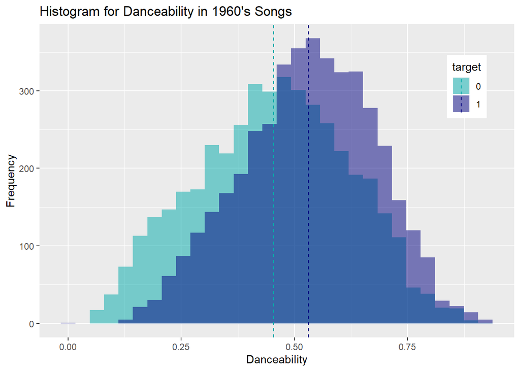

```r
# Set up a conditional for mean lines
danc60Line <- ddply(data1960, "target", summarise, danc.mean=mean(danceability))
danc00Line <- ddply(data2000, "target", summarise, danc.mean=mean(danceability))

# Produce a two part graph for popular and non-popular songs from 1960
ggplot(data = data1960, aes(x = danceability, fill = target)) +
  geom_histogram(position = "identity", alpha = 0.5) +
  labs(title="Histogram for Danceability in 1960's Songs") +
  labs(x="Danceability", y="Frequency") +
  theme(legend.position=c(0.9, 0.8)) +
  scale_color_manual(values=c("#00aaaa", "#000080")) +
  scale_fill_manual(values=c("#00aaaa", "#000080")) +
  geom_vline(data= danc60Line, aes(xintercept=danc.mean, color=target),
             linetype="dashed")
```

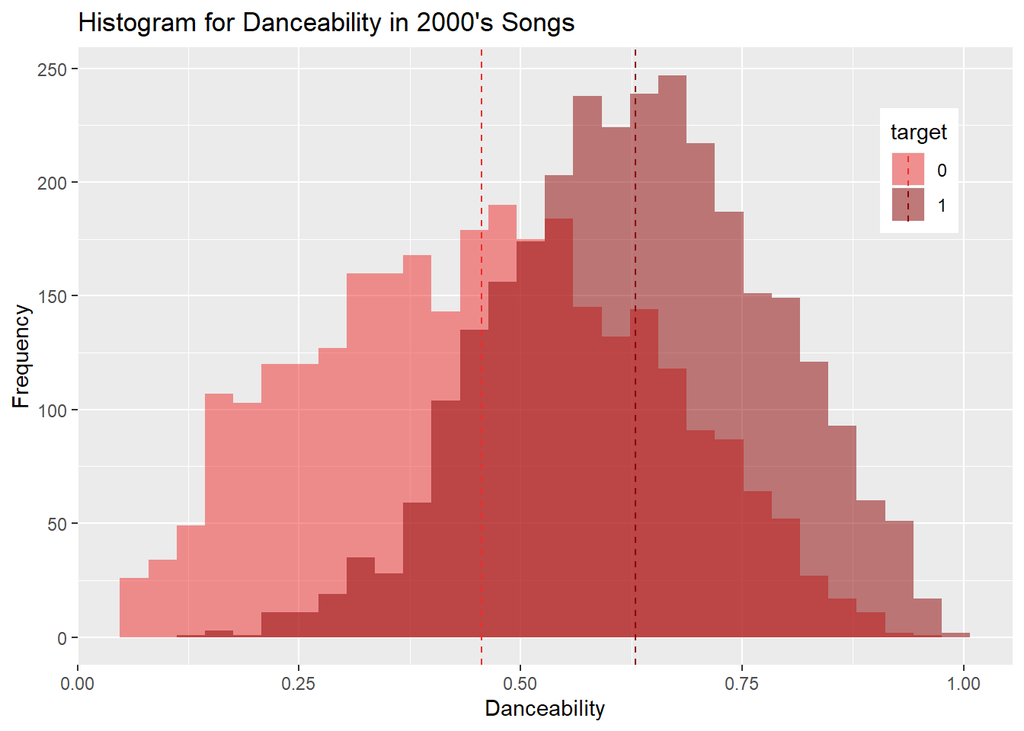

```r
# Produce a two part graph for popular and non-popular songs from 2000
ggplot(data = data2000, aes(x = danceability, fill = target)) +
  geom_histogram(position = "identity", alpha = 0.5) +
  labs(title="Histogram for Danceability in 2000's Songs") +
  labs(x="Danceability", y="Frequency") +
  theme(legend.position=c(0.9, 0.8)) +
  scale_color_manual(values=c("firebrick2", "red4")) +
  scale_fill_manual(values=c("firebrick2", "red4")) +
  geom_vline(data= danc00Line, aes(xintercept=danc.mean, color=target),
             linetype="dashed")
```

From the general trends in the histogram data above, there is a clear right shift in the distribution of danceability values (towards more positive and uplifting qualities) for popular songs in the 1960’s and 2000’s compared to the danceability values of non-popular songs, from an average danceability of 0.531 and 0.63 for popular songs in the 1960’s and 2000’s, respectively, versus 0.454 and 0.456 for non-popular songs in the 1960’s and 2000’s, respectively. In addition, all of the distributions of danceability values appear to be normally-distributed.

The distributions of danceability values for just the popular songs from the two decades under review are presented below:

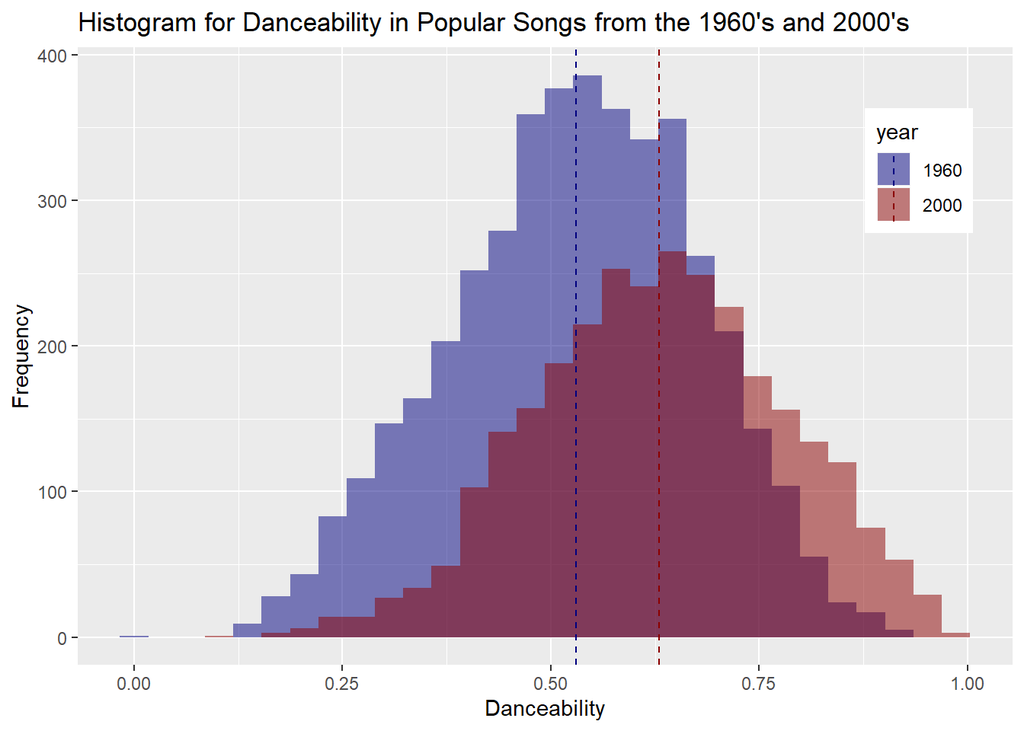

```r
# Set up a conditional for mean lines
dancPopLine <- ddply(dataPopular, "year", summarise, danc.mean=mean(danceability))

# Produce a two part graph for popular and non-popular songs from 1960
ggplot(data = dataPopular, aes(x = danceability, fill = year)) +
  geom_histogram(position = "identity", alpha = 0.5) +
  labs(title="Histogram for Danceability in Popular Songs from the 1960's and 2000's") +
  labs(x="Danceability", y="Frequency") +
  theme(legend.position=c(0.9, 0.8)) +
  scale_color_manual(values=c("#000080", "red4")) +
  scale_fill_manual(values=c("#000080", "red4")) +
  geom_vline(data= dancPopLine, aes(xintercept=danc.mean, color=year),
             linetype="dashed")
```

From the general trend in the histogram data above, it can be seen that the danceability distribution of popular songs is different between the two decades, with the 2000’s trending to higher danceability values in comparison to the 1960’s distribution. The mean danceability of either decade appears to be distinct as well with the 2000’s having a much higher, average danceability value in comparison to the 1960’s. Additional T-Testing may confirm if the two values can be considered statistically different or not.

### 8.5.2 Danceability Normality Testing

The shape of each of the histograms from each decade and popularity appear to be normally-distributed. To confirm this observation, the Shapiro-Wilke Test (H<sub>0</sub>: the data is normally-distributed) identifies the following for each sub-category of decade and popularity for danceability distributions:

**Shapiro-Wilke Normality Test:** 1960’s Popular Probabality Value: 1.161e-11 1960’s Non-Popular Probabality Value: 7.651e-15 2000’s Popular Probabality Value: 9.146e-08 2000’s Non-Popular Probabality Value: 6.428e-15

For all of the categories above, the Shapiro-Wilke probability was significantly less than 0.05 and, thus in contrast to potential appearances, none of the danceability distributions should be considered normally-distributed.

### 8.5.3 Danceability Difference Among Popular Songs Between Decades

Considering only popular music, the mean danceability for 1960’s music is 0.531, and the mean danceability for 2000’s music is 0.63. A Two-Tailed T-Test (H<sub>0</sub>: the two means are statistically equivalent or their true difference in mean value is equal to 0) is performed to determine whether the two mean danceability values from either decade are statistically equivalent:

```r
# Perform t-test
ttest_danc = t.test(subset(data1960,target ==1)$danceability, subset(data2000,target ==1)$danceability)
ttest_danc
```

```
##
##  Welch Two Sample t-test
##
## data:  subset(data1960, target == 1)$danceability and subset(data2000, target == 1)$danceability
## t = -28, df = 6251, p-value <2e-16
## alternative hypothesis: true difference in means is not equal to 0
## 95 percent confidence interval:
##  -0.1064 -0.0925
## sample estimates:
## mean of x mean of y
##     0.531     0.630
```

With a probability value of 1.23510^{-163} (p < 0.025), the T-Test null hypothesis is rejected, and the mean danceability values between the 1960’s and 2000’s decades should **not** be considered equivalent (or their true difference in means is not equal to 0). The 2000’s had a statistically-significant greater average danceability value among popular songs compared to popular songs in the 1960’s.

From the additional T-Testing below, the mean danceability values between popular and non-popular songs from each decade should **not** be considered equivalent (or their true difference in means is not equal to 0)

```r
# Perform tst
ttest_danceability60 = t.test(subset(data1960,target ==0)$danceability, (subset(data1960,target ==1)$danceability))
ttest_danceability60
```

```
##
##  Welch Two Sample t-test
##
## data:  subset(data1960, target == 0)$danceability and (subset(data1960, target == 1)$danceability)
## t = -23, df = 8496, p-value <2e-16
## alternative hypothesis: true difference in means is not equal to 0
## 95 percent confidence interval:
##  -0.0835 -0.0702
## sample estimates:
## mean of x mean of y
##     0.454     0.531
```

```r
ttest_danceability00 = t.test(subset(data2000,target ==0)$danceability, (subset(data2000,target ==1)$danceability))
ttest_danceability00
```

```
##
##  Welch Two Sample t-test
##
## data:  subset(data2000, target == 0)$danceability and (subset(data2000, target == 1)$danceability)
## t = -40, df = 5590, p-value <2e-16
## alternative hypothesis: true difference in means is not equal to 0
## 95 percent confidence interval:
##  -0.183 -0.166
## sample estimates:
## mean of x mean of y
##     0.456     0.630
```

The conclusion of the exploratory data analysis of song danceability in the two datasets from the 1960’s and the 2000’s is no collection of popular or non-popular songs were normally-distributed, and the mean values in danceability were distinct (non-equivalent) between popular and non-popular songs in each decade and between popular songs from each decade.

## 8.6 An Exploration of Energy

### 8.6.1 Energy Histograms

Discussed above, **Energy** represents a perceptual measure of intensity and activity. Typically, energetic tracks feel fast, loud, and noisy. For example, death metal has high energy, while a Bach prelude scores low on the scale. Perceptual features contributing to this attribute include dynamic range, perceived loudness, timbre, onset rate, and general entropy. Danceability is a numerical value between 0 and 1, inclusive. Distributions of the energy values of 8642 songs from the 1960’s and 5872 songs from the 2000’s are presented below with darker shades showing the distributions of the popular songs within each dataset and the mean value of each set represented by a dashed line:

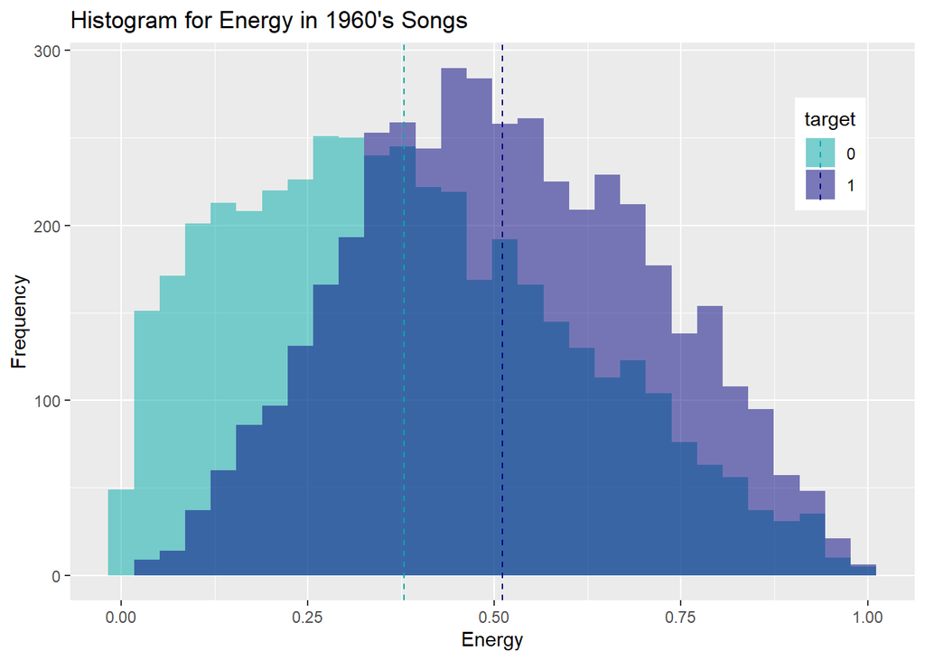

```r
# Set up a conditional for mean lines
energy60Line <- ddply(data1960, "target", summarise, energy.mean=mean(energy))
energy00Line <- ddply(data2000, "target", summarise, energy.mean=mean(energy))

# Produce a two part graph for popular and non-popular songs from 1960
ggplot(data = data1960, aes(x = energy, fill = target)) +
  geom_histogram(position = "identity", alpha = 0.5) +
  labs(title="Histogram for Energy in 1960's Songs") +
  labs(x="Energy", y="Frequency") +
  theme(legend.position=c(0.9, 0.8)) +
  scale_color_manual(values=c("#00aaaa", "#000080")) +
  scale_fill_manual(values=c("#00aaaa", "#000080")) +
  geom_vline(data= energy60Line, aes(xintercept=energy.mean, color=target),
             linetype="dashed")
```

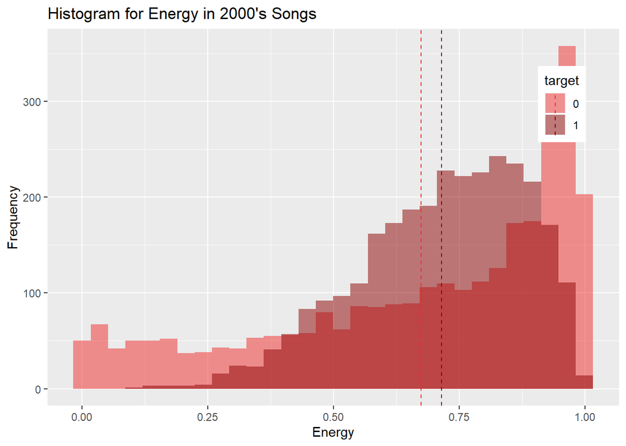

```r
# Produce a two part graph for popular and non-popular songs from 2000
ggplot(data = data2000, aes(x = energy, fill = target)) +
  geom_histogram(position = "identity", alpha = 0.5) +
  labs(title="Histogram for Energy in 2000's Songs") +
  labs(x="Energy", y="Frequency") +
  theme(legend.position=c(0.9, 0.8)) +
  scale_color_manual(values=c("firebrick2", "red4")) +
  scale_fill_manual(values=c("firebrick2", "red4")) +
  geom_vline(data= energy00Line, aes(xintercept=energy.mean, color=target),
             linetype="dashed")
```

The distributions of energy values for just the popular songs from the two decades under review are presented below:

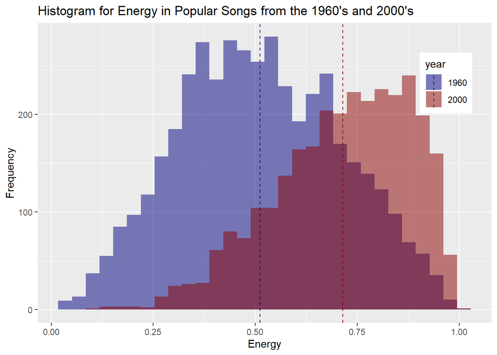

```r
# Set up a conditional for mean lines
energyPopLine <- ddply(dataPopular, "year", summarise, energy.mean=mean(energy))

# Produce a two part graph for popular and non-popular songs from 1960
ggplot(data = dataPopular, aes(x = energy, fill = year)) +
  geom_histogram(position = "identity", alpha = 0.5) +
  labs(title="Histogram for Energy in Popular Songs from the 1960's and 2000's") +
  labs(x="Energy", y="Frequency") +
  theme(legend.position=c(0.9, 0.8)) +
  scale_color_manual(values=c("#000080", "red4")) +
  scale_fill_manual(values=c("#000080", "red4")) +
  geom_vline(data= energyPopLine, aes(xintercept=energy.mean, color=year),
             linetype="dashed")
```

From the general trend in the histogram data above, it can be seen that the energy distribution of popular songs is different between the two decades, with the 2000’s trending to higher energy values in comparison to the 1960’s distribution. The mean energy of either decade appears to be distinct as well with the 2000’s having a much higher, average energy value in comparison to the 1960’s. Additional T-Testing may confirm if the two values can be considered statistically different or not.

### 8.6.2 Energy Normality Testing

The shape of each of the histograms from each decade and popularity do not appear to be normally-distributed. To confirm this observation, the Shapiro-Wilke Test (H<sub>0</sub>: the data is normally-distributed) identifies the following for each sub-category of decade and popularity for energy distributions:

**Shapiro-Wilke Normality Test:** 1960’s Popular Probabality Value: 1.249e-15 1960’s Non-Popular Probabality Value: 4.443e-28 2000’s Popular Probabality Value: 6.185e-26 2000’s Non-Popular Probabality Value: 1.525e-42

For all of the categories above, the Shapiro-Wilke probability was significantly less than 0.05 and, thus, none of the energy distributions should be considered normally-distributed.

### 8.6.3 Energy Difference Among Popular Songs Between Decades

Considering only popular music, the mean energy for 1960’s music is 0.511, and the mean energy for 2000’s music is 0.715. A Two-Tailed T-Test (H<sub>0</sub>: the two means are statistically equivalent or their true difference in mean value is equal to 0) is performed to determine whether the two mean energy values from either decade are statistically equivalent:

```r
# Perform t-test
ttest_energy = t.test(subset(data1960,target ==1)$energy, subset(data2000,target ==1)$energy)
ttest_energy
```

```
##
##  Welch Two Sample t-test
##
## data:  subset(data1960, target == 1)$energy and subset(data2000, target == 1)$energy
## t = -48, df = 6954, p-value <2e-16
## alternative hypothesis: true difference in means is not equal to 0
## 95 percent confidence interval:
##  -0.212 -0.195
## sample estimates:
## mean of x mean of y
##     0.511     0.715
```

With a probability value of 0 (p < 0.025), the T-Test null hypothesis is rejected, and the mean energy values between the 1960’s and 2000’s decades should **not** be considered equivalent (or their true difference in means is not equal to 0). The 2000’s had a statistically-significant greater average energy value among popular songs compared to popular songs in the 1960’s.

From the additional T-Testing below, the mean energy values between popular and non-popular songs from each decade should **not** be considered equivalent (or their true difference in means is not equal to 0)

```r
# Perform tst
ttest_energy60 = t.test(subset(data1960,target ==0)$energy, (subset(data1960,target ==1)$energy))
ttest_energy60
```

```
##
##  Welch Two Sample t-test
##
## data:  subset(data1960, target == 0)$energy and (subset(data1960, target == 1)$energy)
## t = -29, df = 8511, p-value <2e-16
## alternative hypothesis: true difference in means is not equal to 0
## 95 percent confidence interval:
##  -0.141 -0.123
## sample estimates:
## mean of x mean of y
##     0.379     0.511
```

```r
ttest_energy00 = t.test(subset(data2000,target ==0)$energy, (subset(data2000,target ==1)$energy))
ttest_energy00
```

```
##
##  Welch Two Sample t-test
##
## data:  subset(data2000, target == 0)$energy and (subset(data2000, target == 1)$energy)
## t = -6, df = 4624, p-value = 9e-11
## alternative hypothesis: true difference in means is not equal to 0
## 95 percent confidence interval:
##  -0.0523 -0.0281
## sample estimates:
## mean of x mean of y
##     0.674     0.715
```

The conclusion of the exploratory data analysis of song energy in the two datasets from the 1960’s and the 2000’s is no collection of popular or non-popular songs were normally-distributed, and the mean values in energy were distinct (non-equivalent) between popular and non-popular songs in each decade and between popular songs from each decade.

## 8.7 An Exploration of Liveness

### 8.7.1 Liveness Histograms

Discussed above, **Liveness** detects the presence of an audience in the recording. Higher liveness values represent an increased probability that the track was performed live. Liveness is a numerical value between 0 and 1, inclusive. Distributions of the liveness values of 8642 songs from the 1960’s and 5872 songs from the 2000’s are presented below with darker shades showing the distributions of the popular songs within each dataset and the mean value of each set represented by a dashed line:

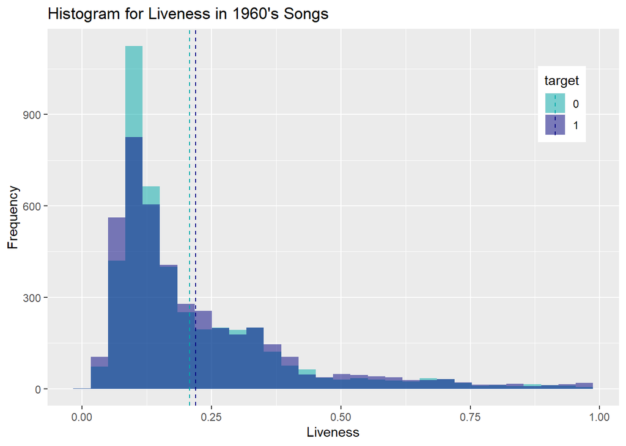

```r
# Set up a conditional for mean lines
live60Line <- ddply(data1960, "target", summarise, live.mean=mean(liveness))
live00Line <- ddply(data2000, "target", summarise, live.mean=mean(liveness))

# Produce a two part graph for popular and non-popular songs from 1960
ggplot(data = data1960, aes(x = liveness, fill = target)) +
  geom_histogram(position = "identity", alpha = 0.5) +
  labs(title="Histogram for Liveness in 1960's Songs") +
  labs(x="Liveness", y="Frequency") +
  theme(legend.position=c(0.9, 0.8)) +
  scale_color_manual(values=c("#00aaaa", "#000080")) +
  scale_fill_manual(values=c("#00aaaa", "#000080")) +
  geom_vline(data= live60Line, aes(xintercept=live.mean, color=target),
             linetype="dashed")
```

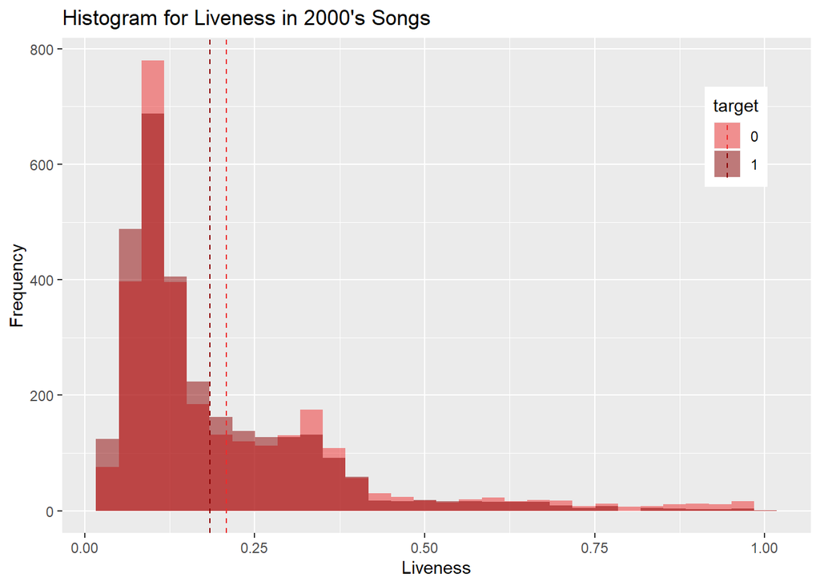

```r
# Produce a two part graph for popular and non-popular songs from 2000
ggplot(data = data2000, aes(x = liveness, fill = target)) +
  geom_histogram(position = "identity", alpha = 0.5) +
  labs(title="Histogram for Liveness in 2000's Songs") +
  labs(x="Liveness", y="Frequency") +
  theme(legend.position=c(0.9, 0.8)) +
  scale_color_manual(values=c("firebrick2", "red4")) +
  scale_fill_manual(values=c("firebrick2", "red4")) +
  geom_vline(data= live00Line, aes(xintercept=live.mean, color=target),
             linetype="dashed")
```

From the general trends in the histogram data above, there is a clear and pronounced left shift in all the distributions of liveness values, potentially identifying a general preference for studio-produced music qualities in producers or listeners. It can be seen that the liveness for popular songs in 1960 skews higher than for non-popular songs, from an average liveness of 0.219 for popular songs versus 0.208 for non-popular songs. Whereas the reverse is true for popular songs in the 2000’s - the liveness for popular songs in 2000 skews lower than for non-popular songs, from an average liveness of 0.184 for popular songs versus 0.208 for non-popular songs.

The distributions of liveness values for just the popular songs from the two decades under review are presented below:

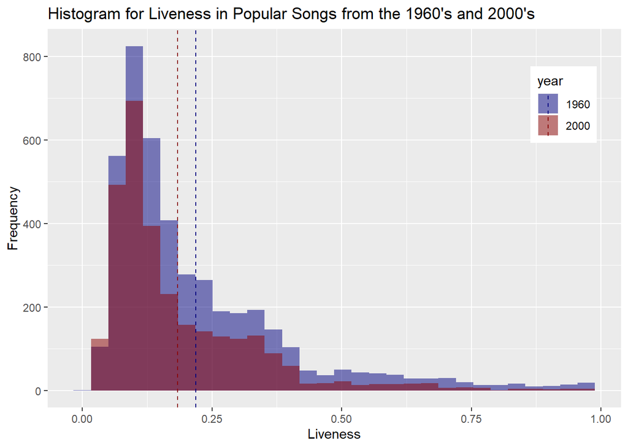

```r
# Set up a conditional for mean lines
livePopLine <- ddply(dataPopular, "year", summarise, live.mean=mean(liveness))

# Produce a two part graph for popular and non-popular songs from 1960
ggplot(data = dataPopular, aes(x = liveness, fill = year)) +
  geom_histogram(position = "identity", alpha = 0.5) +
  labs(title="Histogram for Liveness in Popular Songs from the 1960's and 2000's") +
  labs(x="Liveness", y="Frequency") +
  theme(legend.position=c(0.9, 0.8)) +
  scale_color_manual(values=c("#000080", "red4")) +
  scale_fill_manual(values=c("#000080", "red4")) +
  geom_vline(data= livePopLine, aes(xintercept=live.mean, color=year),
             linetype="dashed")
```

From the general trend in the histogram data above, it can be seen that the liveness distribution of popular songs is different between the two decades, with the 1960’s trending to higher liveness values in comparison to the 2000’s distribution. The mean liveness of either decade appears to be distinct as well with the 1960’s having a higher average liveness value in comparison to the 2000’s. Additional T-Testing may confirm if the two values can be considered statistically different or not.

### 8.7.2 Liveness Normality Testing

The shape of each of the histograms from each decade and popularity do not appear to be normally-distributed. To confirm this observation, the Shapiro-Wilke Test (H<sub>0</sub>: the data is normally-distributed) identifies the following for each sub-category of decade and popularity for liveness distributions:

**Shapiro-Wilke Normality Test:** 1960’s Popular Probabality Value: 1.282e-58 1960’s Non-Popular Probabality Value: 8.994e-61 2000’s Popular Probabality Value: 7.865e-52 2000’s Non-Popular Probabality Value: 3.221e-54

For all of the categories above, the Shapiro-Wilke probability was significantly less than 0.05 and, thus, none of the liveness distributions should be considered normally-distributed.

### 8.7.3 Liveness Difference Among Popular Songs Between Decades

Considering only popular music, the mean liveness for 1960’s music is 0.219, and the mean liveness for 2000’s music is 0.184. A Two-Tailed T-Test (H<sub>0</sub>: the two means are statistically equivalent or their true difference in mean value is equal to 0) is performed to determine whether the two mean liveness values from either decade are statistically equivalent:

```r
# Perform t-test
ttest_liveness = t.test(subset(data1960,target ==1)$liveness, subset(data2000,target ==1)$liveness)
ttest_liveness
```

```
##
##  Welch Two Sample t-test
##
## data:  subset(data1960, target == 1)$liveness and subset(data2000, target == 1)$liveness
## t = 9, df = 6986, p-value <2e-16
## alternative hypothesis: true difference in means is not equal to 0
## 95 percent confidence interval:
##  0.0279 0.0427
## sample estimates:
## mean of x mean of y
##     0.219     0.184
```

With a probability value of 1.23610^{-20} (p < 0.025), the T-Test null hypothesis is rejected, and the mean liveness values between the 1960’s and 2000’s decades should **not** be considered equivalent (or their true difference in means is not equal to 0). The 1960’s had a statistically-significant greater average liveness value among popular songs compared to popular songs in the 2000’s.

From the additional T-Testing below, the mean liveness values between popular and non-popular songs from each decade should **not** be considered equivalent (or their true difference in means is not equal to 0)

```r
# Perform tst
ttest_liveness60 = t.test(subset(data1960,target ==0)$liveness, (subset(data1960,target ==1)$liveness))
ttest_liveness60
```

```
##
##  Welch Two Sample t-test
##
## data:  subset(data1960, target == 0)$liveness and (subset(data1960, target == 1)$liveness)
## t = -3, df = 8597, p-value = 0.002
## alternative hypothesis: true difference in means is not equal to 0
## 95 percent confidence interval:
##  -0.01841 -0.00412
## sample estimates:
## mean of x mean of y
##     0.208     0.219
```

```r
ttest_liveness00 = t.test(subset(data2000,target ==0)$liveness, (subset(data2000,target ==1)$liveness))
ttest_liveness00
```

```
##
##  Welch Two Sample t-test
##
## data:  subset(data2000, target == 0)$liveness and (subset(data2000, target == 1)$liveness)
## t = 6, df = 5650, p-value = 7e-09
## alternative hypothesis: true difference in means is not equal to 0
## 95 percent confidence interval:
##  0.0162 0.0327
## sample estimates:
## mean of x mean of y
##     0.208     0.184
```

The conclusion of the exploratory data analysis of song liveness in the two datasets from the 1960’s and the 2000’s is no collection of popular or non-popular songs were normally-distributed, and the mean values in liveness were distinct (non-equivalent) between popular and non-popular songs in each decade and between popular songs from each decade.

## 8.8 EDA Conclusions

The results of the exploratory data analysis above demonstrate that all of the features within this dataset except one have differing mean values between both the popular and non-popular songs from each decade as well as between popular songs from the 1960’s and 2000’s, and no features had a normal distribution. ‘Key’ is the only musical attribute that does not have a distinct, statistical difference between mean values or distributions between popular and non-popular songs from each decade as well as popular songs from the 1960’s or 2000’s. For this reason, it is not likely that ‘Key’ will be a significant feature in any model, as it is not likely to add any information gain to the models and distinguish between the target variable.

# 9 Model Exploration

The purpose of this study it to identify: Does the key, valence, tempo, or other musical attributes change between popular American songs, and not popular songs for contrast, from the 1960’s versus songs from the early 2000’s? In order to answer this question, this study will utilize three predictive models, K-Nearest Neighbor, Decision Tree, and Logistic Regression, to predict the binary “popularity” feature, popular or not popular. If a model has greater than 50% accuracy in predicting a binary variable, then the model is considered significant (better than random guessing which has an accuracy of 50%). The musical attribute features utilized within significant models are those that have the most significant impact. Accordingly, this study will answer the purpose question by identifying whether each predicitive model is significant and comparing and contrasting the significant musical attributes that appear in the models between popular songs in the 1960s and 2000s.

# 10 K-Nearest Neighbor - Juhne

The project goal is to explore which features determine whether a song is popular or not. K-Nearest Neighbor is a good option to apply on this dataset, because both of our 1960s and 2000s datasets have a lot of numerical features and the target we want to predict on is a catagorical variable which is a perfect situation to apply K-Nearest Neighbor algorithm. Since K-Nearest Neighbor algorithm use distance function to measure distance among each data point, make sure that every predictor has same unit is very important.

On the other hand, since the K-Nearest Neighbor algorithm highly depend on distance function. Cleaning the categorical features like **track and artist** is also very important.

## 10.1 K-Nearest Neighbor Scaling

### 10.1.1 scale (data 2000)

Here we apply simple standard scaling technic which is z-score scaling, that scale our numerical variables with their standard deviation so that all of the scaled numerical variables will have their mean equal to zero. This approach is suitable in most of the time when trying to build model that applies distance function like **Euclidean distance** or **Manhattan distance**.

```r
# scale tempo ~ liveness
df.scaled.20 <- as.data.frame(scale(data2000[3:9], center = TRUE, scale = TRUE))

df.scaled.20$target <- as.factor(data2000$target)

summary(df.scaled.20)
```

```
##      tempo             key              mode           valence
##  Min.   :-2.480   Min.   :-1.480   Min.   :-1.348   Min.   :-1.894
##  1st Qu.:-0.816   1st Qu.:-0.919   1st Qu.:-1.348   1st Qu.:-0.802
##  Median :-0.053   Median :-0.078   Median : 0.742   Median : 0.015
##  Mean   : 0.000   Mean   : 0.000   Mean   : 0.000   Mean   : 0.000
##  3rd Qu.: 0.659   3rd Qu.: 0.764   3rd Qu.: 0.742   3rd Qu.: 0.804
##  Max.   : 3.036   Max.   : 1.606   Max.   : 0.742   Max.   : 1.963
##   danceability        energy          liveness     target
##  Min.   :-2.548   Min.   :-2.919   Min.   :-1.09   0:2936
##  1st Qu.:-0.668   1st Qu.:-0.536   1st Qu.:-0.63   1:2936
##  Median : 0.069   Median : 0.208   Median :-0.40
##  Mean   : 0.000   Mean   : 0.000   Mean   : 0.00
##  3rd Qu.: 0.727   3rd Qu.: 0.801   3rd Qu.: 0.41
##  Max.   : 2.332   Max.   : 1.280   Max.   : 4.88
```

### 10.1.2 scale (data 1960)

We apply z-score scaling on our 1960s dataset as well, so that two K-Nearest Neighbor models we build for both datasets in the future have the closest characteristic. Then, we can compare the features that involved in two models and try to discover the most important features that did not change through time as well as the features that have changed through time that represent the change of taste of music of the audience through 1960s to 2000s.

```r
# scale tempo ~ liveness
df.scaled.60 <- as.data.frame(scale(data1960[3:9], center = TRUE, scale = TRUE))

df.scaled.60$target <- as.factor(data1960$target)

summary(df.scaled.60)
```

```
##      tempo            key              mode           valence
##  Min.   :-3.94   Min.   :-1.471   Min.   :-1.758   Min.   :-2.105
##  1st Qu.:-0.73   1st Qu.:-0.892   1st Qu.: 0.569   1st Qu.:-0.783
##  Median :-0.09   Median :-0.022   Median : 0.569   Median : 0.101
##  Mean   : 0.00   Mean   : 0.000   Mean   : 0.000   Mean   : 0.000
##  3rd Qu.: 0.57   3rd Qu.: 0.847   3rd Qu.: 0.569   3rd Qu.: 0.883
##  Max.   : 4.31   Max.   : 1.717   Max.   : 0.569   Max.   : 1.531
##   danceability        energy          liveness     target
##  Min.   :-3.035   Min.   :-2.019   Min.   :-1.18   0:4321
##  1st Qu.:-0.679   1st Qu.:-0.746   1st Qu.:-0.65   1:4321
##  Median : 0.054   Median :-0.042   Median :-0.39
##  Mean   : 0.000   Mean   : 0.000   Mean   : 0.00
##  3rd Qu.: 0.739   3rd Qu.: 0.739   3rd Qu.: 0.38
##  Max.   : 2.650   Max.   : 2.497   Max.   : 4.55
```

## 10.2 K-Nearest Neighbor Correlation Matrix

### 10.2.1 KNN-correlation matrix of (data 2000)

Before building KNN model, in order to preventing high collinearity between each predictor, it is also necessary to check the correlation between each predictors. From the correlation matrix for 2000s dataset, all predictors are not highly related to each other.

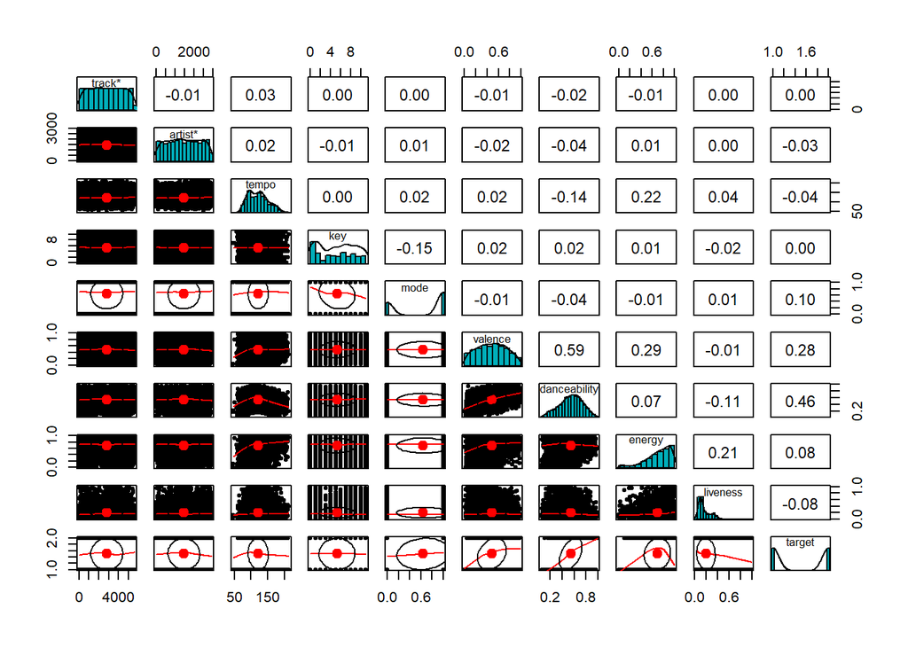

```r
loadPkg('psych')
#pairs(df.scaled.20)
pairs.panels(data2000,
             method = "pearson", # correlation method
             hist.col = "#00AFBB", # set histogram color, can use "#22AFBB", "red",
             density = TRUE,  # show density plots
             ellipses = TRUE # show correlation ellipses
             )
```

### 10.2.2 KNN-correlation matrix of (data 1960)

Here we do the same correlation matrix as before for 1960s model and also looks good. It is time to start building our models.

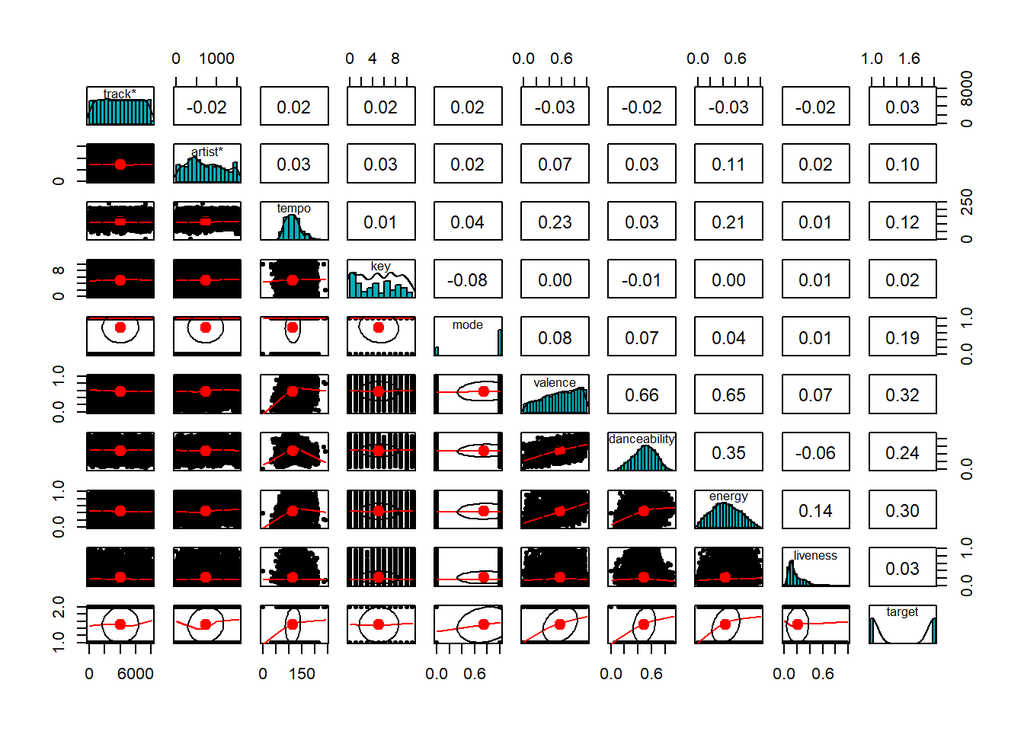

```r
#pairs(df.scaled.60)
pairs.panels(data1960,
             method = "pearson", # correlation method
             hist.col = "#00AFBB", # set histogram color, can use "#22AFBB", "red",
             density = TRUE,  # show density plots
             ellipses = TRUE # show correlation ellipses
             )
```

```r
#unloadPkg('psych')
```

## 10.3 K-Nearest Neighbor Spliting data into train test subsets

### 10.3.1 KNN split data into train test subsets (data 2000)

Since datas are very precious, it is always a good idea to split the original dataset into training and testing subsets. Use training data set to fit KNN model and use testing dataset to test the accuracy of our the model is the best way to utilize the dataset. Set seed to 42 so that the result is reproductable, spliting the original data into 4:1 training and testing subset is a very common ratio to use.

```r
# split data into train test subset, ratio 4:1, seed 42
seed <- 42
## set the seed to make the partition reproducible
set.seed(seed)
## 80% of the sample size
smp_size <- floor(0.80 * nrow(data2000))
# scale tempo ~ liveness
# df.scaled.20 <- as.data.frame(scale(data2000[3:9], center = TRUE, scale = TRUE))
# df.scaled.20$target <- as.factor(data2000$target)
summary(df.scaled.20)
```

```
##      tempo             key              mode           valence
##  Min.   :-2.480   Min.   :-1.480   Min.   :-1.348   Min.   :-1.894
##  1st Qu.:-0.816   1st Qu.:-0.919   1st Qu.:-1.348   1st Qu.:-0.802
##  Median :-0.053   Median :-0.078   Median : 0.742   Median : 0.015
##  Mean   : 0.000   Mean   : 0.000   Mean   : 0.000   Mean   : 0.000
##  3rd Qu.: 0.659   3rd Qu.: 0.764   3rd Qu.: 0.742   3rd Qu.: 0.804
##  Max.   : 3.036   Max.   : 1.606   Max.   : 0.742   Max.   : 1.963
##   danceability        energy          liveness     target
##  Min.   :-2.548   Min.   :-2.919   Min.   :-1.09   0:2936
##  1st Qu.:-0.668   1st Qu.:-0.536   1st Qu.:-0.63   1:2936
##  Median : 0.069   Median : 0.208   Median :-0.40
##  Mean   : 0.000   Mean   : 0.000   Mean   : 0.00
##  3rd Qu.: 0.727   3rd Qu.: 0.801   3rd Qu.: 0.41
##  Max.   : 2.332   Max.   : 1.280   Max.   : 4.88
```

```r
dat20_sample <- sample(2, nrow(df.scaled.20), replace=TRUE, prob=c(0.80, 0.20))
```

### 10.3.2 KNN split data into train test subsets (data 1960)

We do the same spliting process again for our 1960s dataset to keep our entire model building process consistent and comparable.

```r
# split data into train test subset, ratio 4:1, seed 42
seed <- 42
## set the seed to make the partition reproducible
set.seed(seed)
## 80% of the sample size
smp_size <- floor(0.80 * nrow(data1960))
# scale tempo ~ liveness
# df.scaled.20 <- as.data.frame(scale(data2000[3:9], center = TRUE, scale = TRUE))
# df.scaled.20$target <- as.factor(data2000$target)
summary(df.scaled.60)
```

```
##      tempo            key              mode           valence
##  Min.   :-3.94   Min.   :-1.471   Min.   :-1.758   Min.   :-2.105
##  1st Qu.:-0.73   1st Qu.:-0.892   1st Qu.: 0.569   1st Qu.:-0.783
##  Median :-0.09   Median :-0.022   Median : 0.569   Median : 0.101
##  Mean   : 0.00   Mean   : 0.000   Mean   : 0.000   Mean   : 0.000
##  3rd Qu.: 0.57   3rd Qu.: 0.847   3rd Qu.: 0.569   3rd Qu.: 0.883
##  Max.   : 4.31   Max.   : 1.717   Max.   : 0.569   Max.   : 1.531
##   danceability        energy          liveness     target
##  Min.   :-3.035   Min.   :-2.019   Min.   :-1.18   0:4321
##  1st Qu.:-0.679   1st Qu.:-0.746   1st Qu.:-0.65   1:4321
##  Median : 0.054   Median :-0.042   Median :-0.39
##  Mean   : 0.000   Mean   : 0.000   Mean   : 0.00
##  3rd Qu.: 0.739   3rd Qu.: 0.739   3rd Qu.: 0.38
##  Max.   : 2.650   Max.   : 2.497   Max.   : 4.55
```

```r
dat60_sample <- sample(2, nrow(df.scaled.60), replace=TRUE, prob=c(0.80, 0.20))
```

## 10.4 K-Nearest Neighbor Seperate target variable

### 10.4.1 KNN seperate target variable y and predictors X (data 2000)

In order to test accuracy of the fitted models, spliting target variable **target** (1 stands for popular, 0 stands for not popular) variable from the predictors is also necessary.

```r
train.X.20 <- df.scaled.20[dat20_sample==1, 1:7]
train.y.20 <- df.scaled.20[dat20_sample==1, 8]
test.X.20 <- df.scaled.20[dat20_sample==2, 1:7]
test.y.20 <- df.scaled.20[dat20_sample==2, 8]
#dim(test.X.20)[1]/dim(df.scaled.20)[1]
summary(test.X.20)
```

```
##      tempo             key              mode           valence
##  Min.   :-2.480   Min.   :-1.480   Min.   :-1.348   Min.   :-1.827
##  1st Qu.:-0.823   1st Qu.:-0.919   1st Qu.:-1.348   1st Qu.:-0.796
##  Median :-0.053   Median :-0.078   Median : 0.742   Median :-0.029
##  Mean   : 0.007   Mean   : 0.009   Mean   :-0.013   Mean   :-0.014
##  3rd Qu.: 0.709   3rd Qu.: 1.045   3rd Qu.: 0.742   3rd Qu.: 0.769
##  Max.   : 3.036   Max.   : 1.606   Max.   : 0.742   Max.   : 1.951
##   danceability        energy          liveness
##  Min.   :-2.548   Min.   :-2.914   Min.   :-1.09
##  1st Qu.:-0.664   1st Qu.:-0.503   1st Qu.:-0.62
##  Median : 0.032   Median : 0.221   Median :-0.38
##  Mean   :-0.037   Mean   : 0.033   Mean   :-0.02
##  3rd Qu.: 0.670   3rd Qu.: 0.809   3rd Qu.: 0.42
##  Max.   : 2.332   Max.   : 1.276   Max.   : 4.85
```

```r
dim(train.X.20)
```

```
## [1] 4668    7
```

### 10.4.2 KNN seperate target variable y and predictors X (data 1960)

We do the same target separation step for 1960s dataset for later accuracy testing as same as the previous step we did for 2000s dataset.

```r
train.X.60 <- df.scaled.60[dat60_sample==1, 1:7]
train.y.60 <- df.scaled.60[dat60_sample==1, 8]
test.X.60 <- df.scaled.60[dat60_sample==2, 1:7]
test.y.60 <- df.scaled.60[dat60_sample==2, 8]
#dim(test.X.60)[1]/dim(df.scaled.60)[1]
summary(test.X.60)
```

```
##      tempo            key              mode           valence
##  Min.   :-2.85   Min.   :-1.471   Min.   :-1.758   Min.   :-2.105
##  1st Qu.:-0.79   1st Qu.:-0.892   1st Qu.:-1.758   1st Qu.:-0.809
##  Median :-0.12   Median :-0.022   Median : 0.569   Median : 0.086
##  Mean   :-0.02   Mean   : 0.016   Mean   :-0.016   Mean   :-0.028
##  3rd Qu.: 0.58   3rd Qu.: 0.847   3rd Qu.: 0.569   3rd Qu.: 0.835
##  Max.   : 3.18   Max.   : 1.717   Max.   : 0.569   Max.   : 1.531
##   danceability        energy          liveness
##  Min.   :-2.651   Min.   :-2.011   Min.   :-1.12
##  1st Qu.:-0.692   1st Qu.:-0.804   1st Qu.:-0.65
##  Median :-0.020   Median :-0.076   Median :-0.40
##  Mean   :-0.029   Mean   :-0.041   Mean   :-0.03
##  3rd Qu.: 0.708   3rd Qu.: 0.639   3rd Qu.: 0.28
##  Max.   : 2.607   Max.   : 2.497   Max.   : 4.45
```

```r
dim(train.X.60)
```

```
## [1] 6924    7
```

## 10.5 K-Nearest Neighbor helper function to choose best k value

Accuracy is a very important factor to determine the goodness of a fitted KNN model. On the other hand, because of high k-value indicates high precision and high cost on computation, carefully determine the appropriate k-value in order to manage best the trade-off between precision and computation cost is very important. In other word, using the exhaust approach to test a series of k-values and find the most appropriate k-value is the best way to do.

```r
# load class package for knn
loadPkg('class')
# function to selection best k #
chooseK = function(k, train_set, val_set, train_class, val_class){

  # Build knn with k neighbors considered.
  set.seed(1)
  class_knn = knn(train = train_set,    #<- training set cases
                  test = val_set,       #<- test set cases
                  cl = train_class,     #<- category for classification
                  k = k) #,                #<- number of neighbors considered
                  # use.all = TRUE)       #<- control ties between class assignments
                                        #   If true, all distances equal to the kth
                                        #   largest are included

  tab = table(class_knn, val_class)

  # Calculate the accuracy.
  accu = sum(tab[row(tab) == col(tab)]) / sum(tab)
  cbind(k = k, accuracy = accu)
}
```

## 10.6 K-Nearest Neighbor helper function to selection best combination of features with highest accuracy

In order to build the best KNN model with the given datasets to predict whether a music is popular or not. It is necessary to use exhaust approach to build model with all combinations of predictors and decide which combination of predictors can generate the most accurate model.

```r
#features <- combn(names(train.X.20),3)
#features[,1]
#head(train.X.20[,features[,1]])
featureSelectionKNN <- function(train.X, test.X, train.y, test.y){
  res <- data.frame(k = 0, accuracy = 0, features = '')
  for(i in 3:dim(train.X)[2]-1){
    features <- combn(names(train.X),i)
    for(j in 3:dim(features)[2]-1){
      knn_different_k = sapply(seq(3, 21, by = 2),  #<- set k to be odd number from 3 to 21
                         function(x) chooseK(x,
                                             train_set = train.X[,features[,j]],
                                             val_set = test.X[,features[,j]],
                                             train_class = train.y,
                                             val_class = test.y))

      knn_different_k = data.frame(k = knn_different_k[1,],
                             accuracy = knn_different_k[2,])

      new.df = data.frame(k = knn_different_k[order(-knn_different_k$accuracy),][1,1],
                          accuracy = knn_different_k[order(-knn_different_k$accuracy),][1,2],
                          features = paste(features[,j],collapse=" ")
                          )
      res = rbind(res, new.df)
    }
    #print(dim(features)[2])
  }
  res
}
```

## 10.7 KNN feature selection (data 2000)

```r
features.20 = featureSelectionKNN(train.X.20, test.X.20, train.y.20, test.y.20)
# head(test[order(-test$accuracy),])
f.20 <- data.frame(features.20[order(-features.20$accuracy),])
head(f.20)
```

```
##      k accuracy                                        features
## 100 15    0.750      tempo valence danceability energy liveness
## 110 13    0.750 tempo mode valence danceability energy liveness
## 92  17    0.747           tempo key valence danceability energy
## 101 15    0.746            key mode valence danceability energy
## 79  17    0.744                 key valence danceability energy
## 69  21    0.743               tempo valence danceability energy
```

From the above result, the best KNN model for 2000s data after feature selection has accuracy equal to 0.75 with k-value equal 15 and with 5 features which are **tempo, valence, danceability, energy and liveness**.

The alternative option is the second best KNN model with accuracy equal to 0.75 as same as the best model but with lower k-value which equals 13, and 6 instead of 5 features which are **tempo, mode, valence, danceability, energy and liveness**. However, high k-value can cause expensive computation cost and second best KNN model seems to be better than the best KNN model in the list, we still want to minimize the number of involved predictors to be able to explore the most important factors that decide whether a music is popular or not in 2000s.

## 10.8 KNN feature selection (data 1960)

```r
features.60 = featureSelectionKNN(train.X.60, test.X.60, train.y.60, test.y.60)
# head(test[order(-test$accuracy),])
f.60 <- data.frame(features.60[order(-features.60$accuracy),])
head(f.60)
```

```
##      k accuracy                                        features
## 85  19    0.675                    mode valence energy liveness
## 101 21    0.675            key mode valence danceability energy
## 110 11    0.673 tempo mode valence danceability energy liveness
## 64  21    0.672                       tempo mode valence energy
## 83  15    0.671                mode valence danceability energy
## 98  15    0.666              tempo mode valence energy liveness
```

From the above result, the best KNN model for 1960s data after feature selection has accuracy equal to 0.68 with k-value equal 19 and has only 4 features which are **mode, valence, energy and liveness**.

The alternative option is the second best KNN model with accuracy equal to 0.68 as same as the best model but with higher k-value which equals 21, and 5 instead of 4 features which are **key, mode, valence, danceability, energy**. This time the second best KNN model loses on both k-value and number of predictors. So, we choose the best model without doubt as our final KNN model for 1960s dataset.

In conclusion, comparing the best model for 1960s dataset and 2000s dataset, the important features to determine whether a music is popular has changed from **mode, valence, energy and liveness** in 1960s to **tempo, valence, danceability, energy and liveness** in 2000s. In other word, people in 1960s took **mode, valence, energy and liveness** these four music elements as the most important features to determine whether a music is good or not, and has changed in 2000s to **tempo, valence, danceability, energy and liveness** these five music elements. People still think **valence, energy and liveness** are important factors but no longer took **mode** as an important factor. Moreover, took **tempo and danceability** as two new important factors.

##Visualize k-values in the best KNN model (data 2000)

After spotting the best features combination and k-values, it is time for us to start building our KNN model using 2000s dataset with the best subset of features and check correctness of our above **featureSelectionKNN** result. Notice that the best k-value among range 1 through 81 is still 15 which is as same as the result we get from **featureSelectionKNN** function. On the other hand, k-value equal 15 is also the ankle value of the k-values series which also demonstrate that this is the best k-value we are looking for.

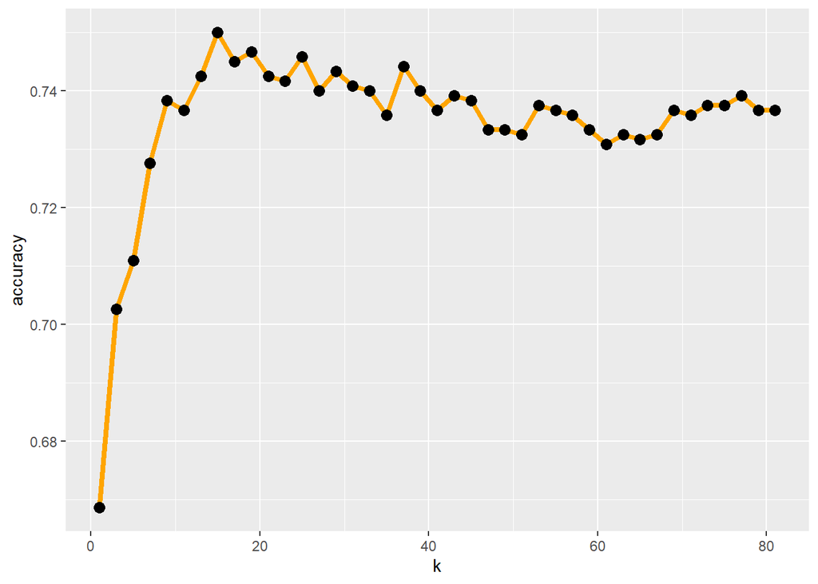

```r
# features selected by features selection function, with the best accuracy
best_features.20 <- c('tempo', 'valence', 'danceability', 'energy', 'liveness')

knn_different_k = sapply(seq(1, 81, by = 2),  #<- set k to be odd number from 1 to 21
                         function(x) chooseK(x,
                                             train_set = train.X.20[,best_features.20],
                                             val_set = test.X.20[,best_features.20],
                                             train_class = train.y.20,
                                             val_class = test.y.20))

# Reformat the results to graph the results.
#str(knn_different_k)
knn_different_k = data.frame(k = knn_different_k[1,],
                             accuracy = knn_different_k[2,])

# Plot accuracy vs. k.
# install.packages("ggplot2")
loadPkg('ggplot2')

ggplot(knn_different_k,
       aes(x = k, y = accuracy)) +
  geom_line(color = "orange", size = 1.5) +
  geom_point(size = 3)
```

```r
#summary(pima$type)[2]/dim(pima)[1]
#head(knn_different_k[order(knn_different_k$accuracy),])
#as.data.frame(knn_different_k[order(-knn_different_k$accuracy),])[1,2]
```

##Visualize k-value trend in the best KNN model (data 1960)

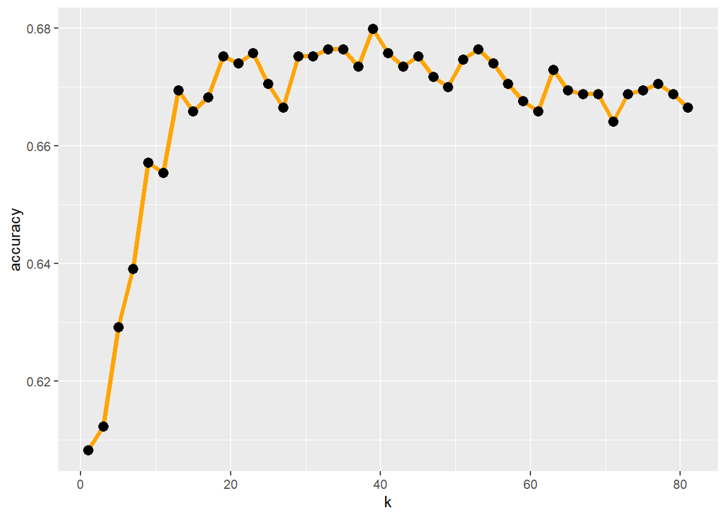

```r
# features selected by features selection function, with the best accuracy
best_features.60 <- c('mode', 'valence', 'energy', 'liveness')

knn_different_k = sapply(seq(1, 81, by = 2),  #<- set k to be odd number from 1 to 21
                         function(x) chooseK(x,
                                             train_set = train.X.60[,best_features.60],
                                             val_set = test.X.60[,best_features.60],
                                             train_class = train.y.60,
                                             val_class = test.y.60))

# Reformat the results to graph the results.
#str(knn_different_k)
knn_different_k = data.frame(k = knn_different_k[1,],
                             accuracy = knn_different_k[2,])

# Plot accuracy vs. k.
# install.packages("ggplot2")
loadPkg('ggplot2')

ggplot(knn_different_k,
       aes(x = k, y = accuracy)) +
  geom_line(color = "orange", size = 1.5) +
  geom_point(size = 3)
```

```r
#summary(pima$type)[2]/dim(pima)[1]
#head(knn_different_k[order(knn_different_k$accuracy),])
#as.data.frame(knn_different_k[order(-knn_different_k$accuracy),])[1,2]
```

# 11 Decision Tree Analysis - Krystal

The main goal of this section is to predict whether the target class of popular and non-popular songs will have different variables that affect them in the 1960s and 2000s. Will the songs have the same variables that matter most in both decades or will they differ?

## 11.1 Grow the Tree

In this section, the study will be using the Categorical Decision Tree to show what makes a song popular in the 1960’s verses the 2000’s. The variables of tempo, key, valence, danceability, energy, liveness, and mode are the independent variables and target will be used as the dependent variable. First, there had to be change made to the variable, ‘target’, so it could be a factor variable. Once this has been done, one can proceed to grow the decision tree by starting at the root and building up. Our root will be target which has already been stated as the dependent variable:

```r
set.seed(1)
data1960_DT <- rpart(target ~ tempo + key + valence + danceability + energy + liveness, data=data1960, method="class", control = list(maxdepth = 10) )
printcp(data1960_DT) # display the results
```

```
##
## Classification tree:
## rpart(formula = target ~ tempo + key + valence + danceability +
##     energy + liveness, data = data1960, method = "class", control = list(maxdepth = 10))
##
## Variables actually used in tree construction:
## [1] energy  valence
##
## Root node error: 4321/8642 = 0.5
##
## n= 8642
##
##     CP nsplit rel error xerror xstd
## 1 0.25      0       1.0    1.0 0.01
## 2 0.06      1       0.8    0.8 0.01
## 3 0.01      2       0.7    0.7 0.01
```

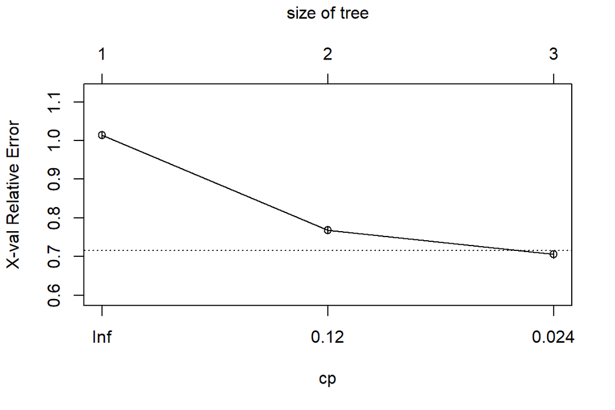

```r
plotcp(data1960_DT) # visualize cross-validation results
```

```r
summary(data1960_DT) # detailed summary of splits
```

```
## Call:
## rpart(formula = target ~ tempo + key + valence + danceability +
##     energy + liveness, data = data1960, method = "class", control = list(maxdepth = 10))
##   n= 8642
##
##       CP nsplit rel error xerror   xstd
## 1 0.2460      0     1.000  1.015 0.0108
## 2 0.0555      1     0.754  0.769 0.0105
## 3 0.0100      2     0.698  0.705 0.0103
##
## Variable importance
##       energy      valence danceability        tempo
##           58           33            7            2
##
## Node number 1: 8642 observations,    complexity param=0.246
##   predicted class=0  expected loss=0.5  P(node) =1
##     class counts:  4321  4321
##    probabilities: 0.500 0.500
##   left son=2 (2015 obs) right son=3 (6627 obs)
##   Primary splits:
##       energy       < 0.27   to the left,  improve=366.0, (0 missing)
##       valence      < 0.336  to the left,  improve=366.0, (0 missing)
##       danceability < 0.436  to the left,  improve=174.0, (0 missing)
##       tempo        < 106    to the left,  improve= 70.3, (0 missing)
##       liveness     < 0.0834 to the right, improve= 15.6, (0 missing)
##   Surrogate splits:
##       valence      < 0.284  to the left,  agree=0.836, adj=0.297, (0 split)
##       danceability < 0.22   to the left,  agree=0.789, adj=0.093, (0 split)
##       tempo        < 70.3   to the left,  agree=0.773, adj=0.026, (0 split)
##
## Node number 2: 2015 observations
##   predicted class=0  expected loss=0.236  P(node) =0.233
##     class counts:  1539   476
##    probabilities: 0.764 0.236
##
## Node number 3: 6627 observations,    complexity param=0.0555
##   predicted class=1  expected loss=0.42  P(node) =0.767
##     class counts:  2782  3845
##    probabilities: 0.420 0.580
##   left son=6 (722 obs) right son=7 (5905 obs)
##   Primary splits:
##       valence      < 0.34   to the left,  improve=98.40, (0 missing)
##       danceability < 0.51   to the left,  improve=70.20, (0 missing)
##       energy       < 0.446  to the left,  improve=56.30, (0 missing)
##       tempo        < 106    to the left,  improve=31.50, (0 missing)
##       liveness     < 0.0844 to the right, improve= 8.71, (0 missing)
##   Surrogate splits:
##       danceability < 0.25   to the left,  agree=0.903, adj=0.111, (0 split)
##       tempo        < 41.5   to the left,  agree=0.891, adj=0.003, (0 split)
##       energy       < 0.27   to the left,  agree=0.891, adj=0.001, (0 split)
##
## Node number 6: 722 observations
##   predicted class=0  expected loss=0.334  P(node) =0.0835
##     class counts:   481   241
##    probabilities: 0.666 0.334
##
## Node number 7: 5905 observations
##   predicted class=1  expected loss=0.39  P(node) =0.683
##     class counts:  2301  3604
##    probabilities: 0.390 0.610
```

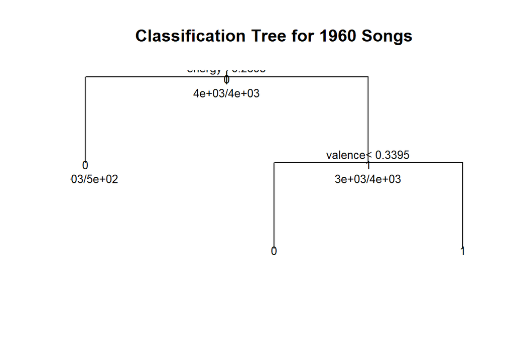

```r
# plot tree
plot(data1960_DT, uniform=TRUE, main="Classification Tree for 1960 Songs")
text(data1960_DT, use.n=TRUE, all=TRUE, cex=.8)
```

```r
set.seed(1)
data2000_DT <- rpart(target ~ tempo + key + valence + danceability + energy + liveness, data=data2000, method="class", control = list(maxdepth = 10) )
printcp(data2000_DT) # display the results
```

```
##
## Classification tree:
## rpart(formula = target ~ tempo + key + valence + danceability +
##     energy + liveness, data = data2000, method = "class", control = list(maxdepth = 10))
##
## Variables actually used in tree construction:
## [1] danceability energy       valence
##
## Root node error: 2936/5872 = 0.5
##
## n= 5872
##
##     CP nsplit rel error xerror xstd
## 1 0.34      0       1.0    1.0 0.01
## 2 0.03      1       0.7    0.7 0.01
## 3 0.03      3       0.6    0.7 0.01
## 4 0.01      4       0.6    0.6 0.01
## 5 0.01      6       0.5    0.5 0.01
```

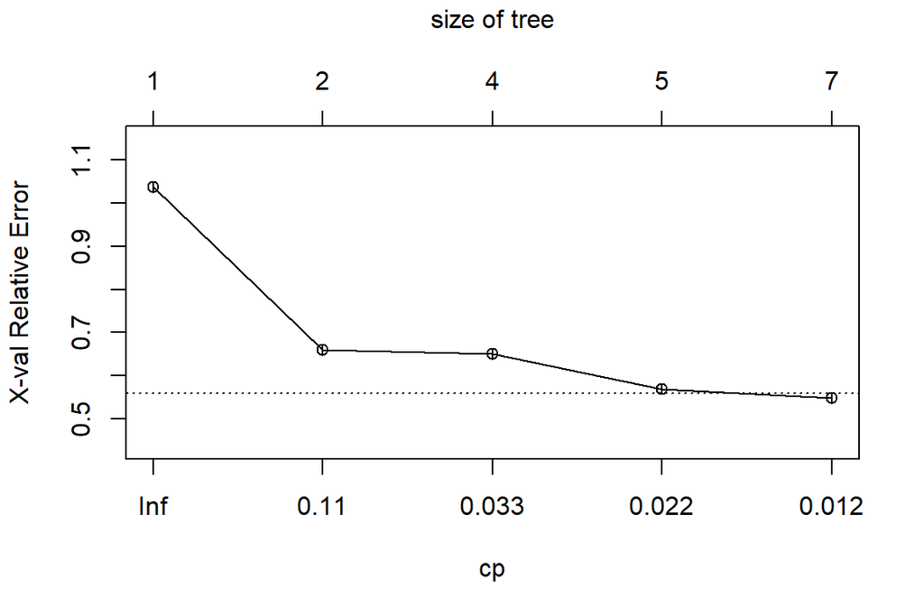

```r
plotcp(data2000_DT) # visualize cross-validation results
```

```r
summary(data2000_DT) # detailed summary of splits
```

```
## Call:
## rpart(formula = target ~ tempo + key + valence + danceability +
##     energy + liveness, data = data2000, method = "class", control = list(maxdepth = 10))
##   n= 5872
##
##       CP nsplit rel error xerror   xstd
## 1 0.3423      0     1.000  1.037 0.0130
## 2 0.0332      1     0.658  0.659 0.0123
## 3 0.0324      3     0.591  0.651 0.0122
## 4 0.0150      4     0.559  0.569 0.0118
## 5 0.0100      6     0.529  0.548 0.0116
##
## Variable importance
## danceability       energy      valence        tempo
##           61           20           15            3
##
## Node number 1: 5872 observations,    complexity param=0.342
##   predicted class=0  expected loss=0.5  P(node) =1
##     class counts:  2936  2936
##    probabilities: 0.500 0.500
##   left son=2 (1319 obs) right son=3 (4553 obs)
##   Primary splits:
##       danceability < 0.396  to the left,  improve=494.0, (0 missing)
##       valence      < 0.19   to the left,  improve=244.0, (0 missing)
##       energy       < 0.29   to the left,  improve=194.0, (0 missing)
##       liveness     < 0.322  to the right, improve= 15.9, (0 missing)
##       tempo        < 70.9   to the left,  improve= 14.6, (0 missing)
##   Surrogate splits:
##       valence  < 0.124  to the left,  agree=0.825, adj=0.219, (0 split)
##       energy   < 0.232  to the left,  agree=0.804, adj=0.127, (0 split)
##       tempo    < 70.9   to the left,  agree=0.783, adj=0.032, (0 split)
##       liveness < 0.934  to the right, agree=0.776, adj=0.004, (0 split)
##
## Node number 2: 1319 observations
##   predicted class=0  expected loss=0.119  P(node) =0.225
##     class counts:  1162   157
##    probabilities: 0.881 0.119
##
## Node number 3: 4553 observations,    complexity param=0.0332
##   predicted class=1  expected loss=0.39  P(node) =0.775
```

[output cut: 83 more lines]

```
##       energy       < 0.538  to the left,  improve= 7.860, (0 missing)
##       liveness     < 0.278  to the right, improve= 6.740, (0 missing)
##       danceability < 0.398  to the right, improve= 0.948, (0 missing)
##   Surrogate splits:
##       tempo < 200    to the right, agree=0.822, adj=0.009, (0 split)
##
## Node number 54: 214 observations
##   predicted class=0  expected loss=0.397  P(node) =0.0364
##     class counts:   129    85
##    probabilities: 0.603 0.397
##
## Node number 55: 976 observations
##   predicted class=1  expected loss=0.376  P(node) =0.166
##     class counts:   367   609
##    probabilities: 0.376 0.624
```

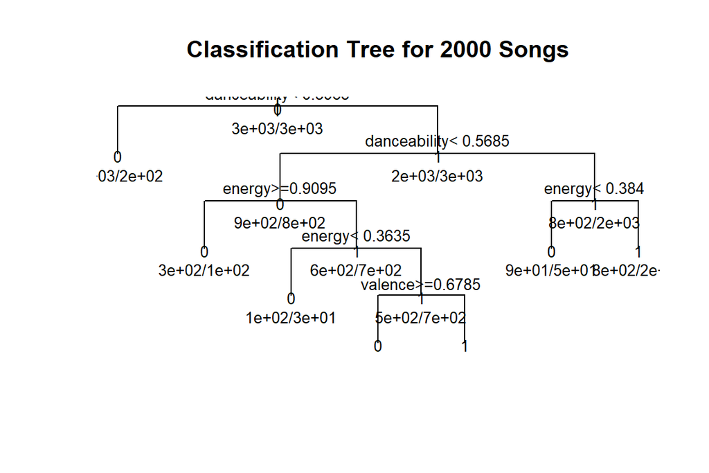

```r
# plot tree
plot(data2000_DT, uniform=TRUE, main="Classification Tree for 2000 Songs")
text(data2000_DT, use.n=TRUE, all=TRUE, cex=.8)
```

```r
# create attractive postcript plot of tree
post(data1960_DT, file = "data1960.ps", title = "Classification Tree for 1960s Song List")
post(data2000_DT, file = "data2000.ps", title = "Classification Tree for 2000s Song List")
```

Here are the results.

For the 1960’s Song List: From the decision tree, the first branching point has 4321 popular and 4321 unpopular songs from the data. The first split yields 2015 outcomes with energy levels < 0.27 and 6627 outcomes with energy levels >= 0.27 from the popularity results for the song list. The energy level was shown as being the most important variable to determine whether the song was popular or not. The energy level being under 0.27 represents that the song was more likely to be unpopular and the energy level greater than 0.27 deems the song was more likely to be popular. The variable that follows after the energy level was the variance level. There were only two variables that determined the popularity of the songs making the Billboard Top 100 list. For the song to more liekly be considered popular, the energy of the song has to be equal to or greater than 0.27. A further split on the left node might not have been beneficial to separate the popular and unpopular songs list. The algorithm actually stops there, and more likely predicts an unpopular rating for all 2015 observations, giving 476/2015 incorrect predictions.

From the decision tables above we see that what made a song popular in the 1960’s did not necessarily make a song popular in the 2000’s. They had one differing variable that made the difference. In the 2000s, the most important variable for the song to make the Billboard’s Top 100 list was for the song to have danceability. A song like ‘Hot in Herre’ by Nelly has the high danceability that is discussed above. In the 1960’s, a song needed to have energy as the most important variable. We can check our decision tables by creating confusion matrixes.

These perentages for both the 1960’s and 2000’s songs can be represented by the calculations below that are being examined in confusion matrixes.

```r
loadPkg('caret')
cm_1960 = confusionMatrix( predict(data1960_DT, type = "class"), reference = data1960[, "target"] )
print('Overall: ')
```

```
## [1] "Overall: "
```

```r
cm_1960$overall
```

```
##       Accuracy          Kappa  AccuracyLower  AccuracyUpper   AccuracyNull
##       6.51e-01       3.02e-01       6.41e-01       6.61e-01       5.00e-01
## AccuracyPValue  McnemarPValue
##      9.11e-176      1.38e-182
```

```r
print('Class: ')
```

```
## [1] "Class: "
```

```r
cm_1960$byClass
```

```
##          Sensitivity          Specificity       Pos Pred Value
##                0.467                0.834                0.738
##       Neg Pred Value            Precision               Recall
##                0.610                0.738                0.467
##                   F1           Prevalence       Detection Rate
##                0.572                0.500                0.234
## Detection Prevalence    Balanced Accuracy
##                0.317                0.651
```

```r
xkabledply(cm_1960$table, "confusion matrix")
```

confusion matrix

|  | 0 | 1 |
| --- | --- | --- |
| 0 | 2020 | 717 |
| 1 | 2301 | 3604 |

```r
cm_2000 = confusionMatrix( predict(data2000_DT, type = "class"), reference = data2000[, "target"] )
print('Overall: ')
```

```
## [1] "Overall: "
```

```r
cm_2000$overall
```

```
##       Accuracy          Kappa  AccuracyLower  AccuracyUpper   AccuracyNull
##       7.36e-01       4.71e-01       7.24e-01       7.47e-01       5.00e-01
## AccuracyPValue  McnemarPValue
##      6.60e-297       1.75e-67
```

```r
print('Class: ')
```

```
## [1] "Class: "
```

```r
cm_2000$byClass
```

```
##          Sensitivity          Specificity       Pos Pred Value
##                0.619                0.852                0.807
##       Neg Pred Value            Precision               Recall
##                0.691                0.807                0.619
##                   F1           Prevalence       Detection Rate
##                0.701                0.500                0.309
## Detection Prevalence    Balanced Accuracy
##                0.383                0.736
```

```r
unloadPkg('caret')
```

```r
xkabledply(cm_2000$table, "confusion matrix")
```

confusion matrix

|  | 0 | 1 |
| --- | --- | --- |
| 0 | 1817 | 434 |
| 1 | 1119 | 2502 |

Now that the calculations are calculated in the confusion matrix, another method can be used, and it uses the ‘maxdepth’ with the results being put into a summary below.

1960’s Song Max Depth Summary:

```r
loadPkg('rpart')
loadPkg('caret')
# create an empty dataframe to store the results from confusion matrices
confusionMatrixResultDf_1 = data.frame( Depth=numeric(0), Accuracy= numeric(0), Sensitivity=numeric(0), Specificity=numeric(0), Pos.Pred.Value=numeric(0), Neg.Pred.Value=numeric(0), Precision=numeric(0), Recall=numeric(0), F1=numeric(0), Prevalence=numeric(0), Detection.Rate=numeric(0), Detection.Prevalence=numeric(0), Balanced.Accuracy=numeric(0), row.names = NULL )
for (deep in 2:6) {
  fit1960 <- rpart(target ~ tempo + key + valence + danceability + energy + liveness, data=data1960, method="class", control = list(maxdepth = deep) )
  #
  cm_1 = confusionMatrix( predict(fit1960, type = "class"), reference = data1960[, "target"] ) # from caret library
  #
  cmaccu_1 = cm_1$overall['Accuracy']
  # print( paste("Total Accuracy = ", cmaccu ) )
  #
  cmt_1 = data.frame(Depth=deep, Accuracy = cmaccu_1, row.names = NULL ) # initialize a row of the metrics
  cmt_1 = cbind( cmt_1, data.frame( t(cm_1960$byClass) ) ) # the dataframe of the transpose, with k valued added in front
  confusionMatrixResultDf_1 = rbind(confusionMatrixResultDf_1, cmt_1)
  # print("Other metrics : ")
}
```

The summarized result is here:

```r
xkabledply(confusionMatrixResultDf_1, "1960s Song List Classification Trees summary with varying MaxDepth")
```

1960s Song List Classification Trees summary with varying MaxDepth

| Depth | Accuracy | Sensitivity | Specificity | Pos.Pred.Value | Neg.Pred.Value | Precision | Recall | F1 | Prevalence | Detection.Rate | Detection.Prevalence | Balanced.Accuracy |
| --- | --- | --- | --- | --- | --- | --- | --- | --- | --- | --- | --- | --- |
| 2 | 0.651 | 0.468 | 0.834 | 0.738 | 0.61 | 0.738 | 0.468 | 0.572 | 0.5 | 0.234 | 0.317 | 0.651 |
| 3 | 0.651 | 0.468 | 0.834 | 0.738 | 0.61 | 0.738 | 0.468 | 0.572 | 0.5 | 0.234 | 0.317 | 0.651 |
| 4 | 0.651 | 0.468 | 0.834 | 0.738 | 0.61 | 0.738 | 0.468 | 0.572 | 0.5 | 0.234 | 0.317 | 0.651 |
| 5 | 0.651 | 0.468 | 0.834 | 0.738 | 0.61 | 0.738 | 0.468 | 0.572 | 0.5 | 0.234 | 0.317 | 0.651 |
| 6 | 0.651 | 0.468 | 0.834 | 0.738 | 0.61 | 0.738 | 0.468 | 0.572 | 0.5 | 0.234 | 0.317 | 0.651 |

2000s Song Max Depth Summary:

```r
# create an empty dataframe to store the results from confusion matrices
confusionMatrixResultDf_2 = data.frame( Depth=numeric(0), Accuracy= numeric(0), Sensitivity=numeric(0), Specificity=numeric(0), Pos.Pred.Value=numeric(0), Neg.Pred.Value=numeric(0), Precision=numeric(0), Recall=numeric(0), F1=numeric(0), Prevalence=numeric(0), Detection.Rate=numeric(0), Detection.Prevalence=numeric(0), Balanced.Accuracy=numeric(0), row.names = NULL )
for (deep in 2:6) {
  fit2000 <- rpart(target ~ tempo + key + valence + danceability + energy + liveness, data=data2000, method="class", control = list(maxdepth = deep) )
  #
  cm_2 = confusionMatrix( predict(fit2000, type = "class"), reference = data2000[, "target"] ) # from caret library
  #
  cmaccu_2 = cm_2$overall['Accuracy']
  # print( paste("Total Accuracy = ", cmaccu ) )
  #
  cmt_2 = data.frame(Depth=deep, Accuracy = cmaccu_2, row.names = NULL ) # initialize a row of the metrics
  cmt_2 = cbind( cmt_2, data.frame( t(cm_2$byClass) ) ) # the dataframe of the transpose, with k valued added in front
  confusionMatrixResultDf_2 = rbind(confusionMatrixResultDf_2, cmt_2)
  # print("Other metrics : ")
}
unloadPkg('caret')
```

The summarized result is here:

```r
xkabledply(confusionMatrixResultDf_2, "2000s Song List Classification Trees summary with varying MaxDepth")
```

2000s Song List Classification Trees summary with varying MaxDepth

| Depth | Accuracy | Sensitivity | Specificity | Pos.Pred.Value | Neg.Pred.Value | Precision | Recall | F1 | Prevalence | Detection.Rate | Detection.Prevalence | Balanced.Accuracy |
| --- | --- | --- | --- | --- | --- | --- | --- | --- | --- | --- | --- | --- |
| 2 | 0.687 | 0.713 | 0.660 | 0.677 | 0.697 | 0.677 | 0.713 | 0.695 | 0.5 | 0.357 | 0.526 | 0.687 |
| 3 | 0.712 | 0.533 | 0.891 | 0.830 | 0.656 | 0.830 | 0.533 | 0.649 | 0.5 | 0.267 | 0.321 | 0.712 |
| 4 | 0.728 | 0.575 | 0.881 | 0.829 | 0.675 | 0.829 | 0.575 | 0.679 | 0.5 | 0.287 | 0.347 | 0.728 |
| 5 | 0.736 | 0.619 | 0.852 | 0.807 | 0.691 | 0.807 | 0.619 | 0.701 | 0.5 | 0.309 | 0.383 | 0.736 |
| 6 | 0.736 | 0.619 | 0.852 | 0.807 | 0.691 | 0.807 | 0.619 | 0.701 | 0.5 | 0.309 | 0.383 | 0.736 |

The following are two additional ways that we can plot out the categorical decision tree. The additional methods are the ‘rpart.plot’ and ‘fancy’ plots to help read the tree easier. Both the 1960’s and 2000’s songs have been placed into the models as follows:

1960’s Song Fancy and Rpart Plots

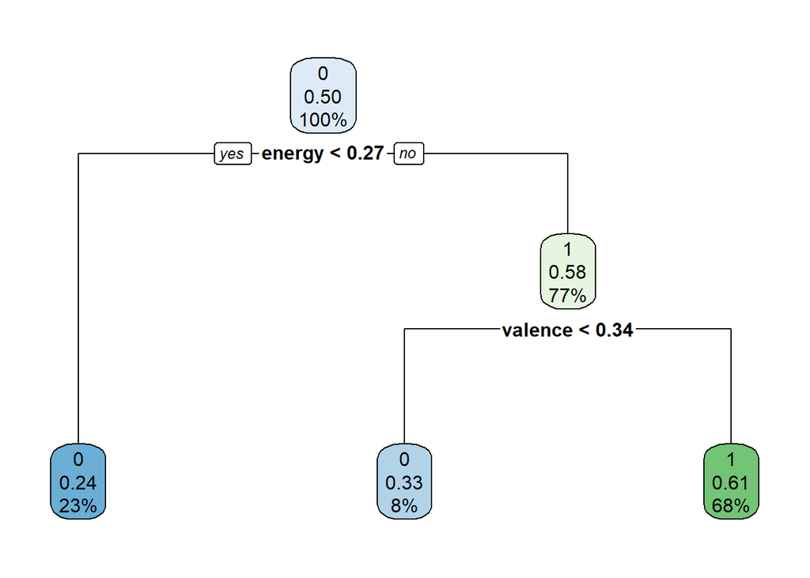

```r
loadPkg("rpart.plot")
rpart.plot(data1960_DT)
```